# Projet Transverses NBA

Ahmed AYOUBI

2025-04-14

[figure not shown]

[figure not shown]

# Optimisation des Équipes NBA

#### Auteur : Ahmed AYOUBI et Yanis Choukoukou

**Date :** 14 avril 2025

## **1.Introduction**

### *Contexte et Objectifs de l’Étude*

> *« Les données ne remplacent pas l’intuition, mais elles la guident. »*

Dans le contexte hautement compétitif de la **National Basketball Association (NBA)**, la construction d’équipes performantes constitue un enjeu majeur pour les directeurs sportifs et les entraîneurs. Si l’intuition et l’expertise humaine demeurent essentielles, l’**analyse statistique** offre aujourd’hui des perspectives inégalées pour **optimiser les effectifs** en s’appuyant sur des critères objectifs et quantifiables.

Cette étude s’inscrit pleinement dans la mouvance des approches **data-driven** du sport professionnel, popularisées notamment par le mouvement *Moneyball* dans le baseball, et désormais largement adoptées en basketball. Notre ambition est de tirer parti des **données statistiques individuelles** des joueurs NBA afin d’identifier les combinaisons de profils les plus propices à la performance collective.

Le jeu de données utilisé repose sur un échantillon de **736 joueurs**, pour lesquels sont recensés à la fois :

- des **indicateurs classiques** (minutes jouées, matchs disputés),
- et des **métriques avancées** telles que :
  - le *Player Efficiency Rating (PER)*,
  - le *Win Shares (WS)*,
  - et le *Box Plus/Minus (BPM)*.

Ce riche corpus constitue une **base robuste pour nos investigations**.

### *Problématiques Guidant l’Analyse*

À travers une démarche rigoureuse combinant **statistiques descriptives**, **tests d’hypothèses**, **modélisation** et **techniques de classification**, nous chercherons à répondre à plusieurs questions fondamentales :

- *Quels profils de joueurs contribuent le plus significativement au succès collectif ?*
- *Comment les différentes métriques individuelles se corrèlent-elles avec la performance d’équipe ?*
- *Peut-on identifier des groupes homogènes de joueurs partageant des caractéristiques statistiques similaires ?*
- ️ *Quelle combinaison optimale de profils permettrait de construire une équipe compétitive selon différentes contraintes (budget, style de jeu, etc.) ?*

### *Une Étude à Double Portée : Scientifique et Stratégique*

Cette analyse ne vise pas uniquement un objectif académique : elle se veut également **opérationnelle**, en proposant des **recommandations concrètes** à destination des décideurs NBA (managers, scouts, analystes), avec pour ambition de contribuer à **l’évolution des pratiques de gestion sportive** dans l’une des ligues les plus exigeantes au monde.

### *Méthodologie Adoptée*

La méthodologie suivra une **progression logique et structurée** :

1. **Exploration et nettoyage des données**
2. **Analyse univariée** (distributions, moyennes, extrêmes)
3. **Analyse bivariée** (corrélations, tests, modélisation)
4. **Analyse multivariée** (ACP, classification, clustering)
5. **Modélisation prédictive** (GLM, ANOVA, régression linéaire)

> Une attention particulière sera portée à la **validation statistique des résultats**, et à leur **interprétation dans le contexte spécifique du basketball professionnel**.

## **2. Chargement et Préparation des Données**

### *2.1 Méthodologie*

Notre analyse débute par une **phase critique** de chargement et de préparation des données issues des statistiques des joueurs NBA. Cette étape fondamentale vise à construire un socle analytique robuste en transformant les données brutes en un format exploitable.

Nous procédons d’abord à l’importation du jeu de données comportant **736 observations** et **29 variables**, représentant divers indicateurs de performance des joueurs. Une attention particulière est portée à :

- La vérification de la **structure des données**,
- La détection des **types de variables** (numériques, catégorielles),
- L’identification des **valeurs aberrantes** ou manquantes (notamment les entrées “NaN” présentes dans plusieurs métriques avancées).

Cette phase préliminaire inclut également la :

- **Standardisation des noms de variables**,
- L’élimination des **colonnes redondantes** ou peu informatives,
- La **création de variables dérivées** pertinentes pour l’analyse.

La qualité de cette préparation conditionne directement la **fiabilité des analyses** ultérieures et constitue un prérequis essentiel à toute **interprétation statistique valide** des performances des joueurs NBA.

| Nous débutons par l’importation du jeu de données principal qui contient des statistiques avancées sur les joueurs NBA. |
| --- |

**Affichage des premières lignes du jeu de données**

```r
head(data)
```

| Rk | Player | Age | Team | Pos | G | GS | MP | PER | TS% | 3PAr | FTr | ORB% | DRB% | TRB% | AST% | STL% | BLK% | TOV% | USG% | OWS | DWS | WS | WS/48 | OBPM | DBPM | BPM | VORP | Player-additional |
| --- | --- | --- | --- | --- | --- | --- | --- | --- | --- | --- | --- | --- | --- | --- | --- | --- | --- | --- | --- | --- | --- | --- | --- | --- | --- | --- | --- | --- |
| 1 | DeMar DeRozan | 34 | CHI | SF | 79 | 79 | 2989 | 19.7 | .584 | .166 | .452 | 1.6 | 11.3 | 6.4 | 21.8 | 1.5 | 1.5 | 7.7 | 25.8 | 7.0 | 2.2 | 9.2 | .147 | 2.1 | -0.3 | 1.8 | 2.8 | derozde01 |
| 2 | Domantas Sabonis | 27 | SAC | C | 82 | 82 | 2928 | 23.2 | .637 | .081 | .389 | 11.0 | 32.3 | 21.4 | 33.9 | 1.2 | 1.5 | 17.9 | 22.2 | 8.6 | 4.0 | 12.6 | .206 | 4.0 | 2.4 | 6.5 | 6.2 | sabondo01 |
| 3 | Coby White | 23 | CHI | PG | 79 | 78 | 2881 | 14.5 | .570 | .460 | .215 | 1.7 | 12.4 | 6.9 | 20.8 | 0.9 | 0.6 | 11.1 | 22.7 | 3.1 | 1.6 | 4.7 | .078 | 0.7 | -1.3 | -0.7 | 0.9 | whiteco01 |
| 4 | Mikal Bridges | 27 | BRK | SF | 82 | 82 | 2854 | 14.9 | .560 | .457 | .245 | 2.5 | 12.0 | 7.1 | 16.3 | 1.4 | 0.9 | 10.3 | 24.3 | 2.1 | 2.1 | 4.2 | .070 | 0.7 | -1.0 | -0.4 | 1.2 | bridgmi01 |
| 5 | Paolo Banchero | 21 | ORL | PF | 80 | 80 | 2799 | 17.3 | .546 | .249 | .397 | 3.4 | 20.0 | 11.6 | 25.2 | 1.3 | 1.6 | 13.0 | 29.7 | 1.3 | 4.0 | 5.3 | .090 | 1.3 | 0.0 | 1.3 | 2.3 | banchpa01 |
| 6 | Kevin Durant | 35 | PHO | PF | 75 | 75 | 2791 | 21.2 | .626 | .283 | .295 | 1.7 | 17.5 | 10.0 | 22.2 | 1.2 | 2.9 | 13.1 | 29.0 | 5.1 | 3.2 | 8.3 | .142 | 4.0 | 0.1 | 4.0 | 4.3 | duranke01 |

**Statistiques descriptives du jeu de données**

```r
summary(data)
```

```
##        Rk           Player               Age            Team
##  Min.   :  1.0   Length:736         Min.   :19.00   Length:736
##  1st Qu.:184.5   Class :character   1st Qu.:23.00   Class :character
##  Median :368.0   Mode  :character   Median :25.00   Mode  :character
##  Mean   :368.0                      Mean   :26.16
##  3rd Qu.:551.5                      3rd Qu.:29.00
##  Max.   :735.0                      Max.   :39.00
##  NA's   :1                          NA's   :1
##      Pos                  G               GS              MP
##  Length:736         Min.   : 1.00   Min.   : 0.00   Min.   :   1.0
##  Class :character   1st Qu.:17.00   1st Qu.: 0.00   1st Qu.: 160.0
##  Mode  :character   Median :41.00   Median : 5.00   Median : 680.0
##                     Mean   :40.88   Mean   :18.44   Mean   : 907.8
##                     3rd Qu.:64.50   3rd Qu.:29.00   3rd Qu.:1527.5
##                     Max.   :84.00   Max.   :82.00   Max.   :2989.0
##                     NA's   :1       NA's   :1       NA's   :1
##      PER                TS%                3PAr               FTr
##  Length:736         Length:736         Length:736         Length:736
##  Class :character   Class :character   Class :character   Class :character
##  Mode  :character   Mode  :character   Mode  :character   Mode  :character
##
##
##
##
##      ORB%               DRB%               TRB%               AST%
##  Length:736         Length:736         Length:736         Length:736
##  Class :character   Class :character   Class :character   Class :character
##  Mode  :character   Mode  :character   Mode  :character   Mode  :character
##
##
##
##
##      STL%               BLK%               TOV%               USG%
##  Length:736         Length:736         Length:736         Length:736
##  Class :character   Class :character   Class :character   Class :character
##  Mode  :character   Mode  :character   Mode  :character   Mode  :character
##
##
##
##
```

[output cut: 9 more lines]

```
##  Length:736         Length:736         Length:736         Length:736
##  Class :character   Class :character   Class :character   Class :character
##  Mode  :character   Mode  :character   Mode  :character   Mode  :character
##
##
##
##
##  Player-additional
##  Length:736
##  Class :character
##  Mode  :character
##
##
##
##
```

**Vérification des types de données**

```r
str(data)
```

```
## tibble [736 × 29] (S3: tbl_df/tbl/data.frame)
##  $ Rk               : num [1:736] 1 2 3 4 5 6 7 8 9 10 ...
##  $ Player           : chr [1:736] "DeMar DeRozan" "Domantas Sabonis" "Coby White" "Mikal Bridges" ...
##  $ Age              : num [1:736] 34 27 23 27 21 35 27 22 28 27 ...
##  $ Team             : chr [1:736] "CHI" "SAC" "CHI" "BRK" ...
##  $ Pos              : chr [1:736] "SF" "C" "PG" "SF" ...
##  $ G                : num [1:736] 79 82 79 82 80 75 78 79 79 77 ...
##  $ GS               : num [1:736] 79 82 78 82 80 75 78 78 79 77 ...
##  $ MP               : num [1:736] 2989 2928 2881 2854 2799 ...
##  $ PER              : chr [1:736] "19.7" "23.2" "14.5" "14.9" ...
##  $ TS%              : chr [1:736] ".584" ".637" ".570" ".560" ...
##  $ 3PAr             : chr [1:736] ".166" ".081" ".460" ".457" ...
##  $ FTr              : chr [1:736] ".452" ".389" ".215" ".245" ...
##  $ ORB%             : chr [1:736] "1.6" "11.0" "1.7" "2.5" ...
##  $ DRB%             : chr [1:736] "11.3" "32.3" "12.4" "12.0" ...
##  $ TRB%             : chr [1:736] "6.4" "21.4" "6.9" "7.1" ...
##  $ AST%             : chr [1:736] "21.8" "33.9" "20.8" "16.3" ...
##  $ STL%             : chr [1:736] "1.5" "1.2" "0.9" "1.4" ...
##  $ BLK%             : chr [1:736] "1.5" "1.5" "0.6" "0.9" ...
##  $ TOV%             : chr [1:736] "7.7" "17.9" "11.1" "10.3" ...
##  $ USG%             : chr [1:736] "25.8" "22.2" "22.7" "24.3" ...
##  $ OWS              : chr [1:736] "7.0" "8.6" "3.1" "2.1" ...
##  $ DWS              : chr [1:736] "2.2" "4.0" "1.6" "2.1" ...
##  $ WS               : chr [1:736] "9.2" "12.6" "4.7" "4.2" ...
##  $ WS/48            : chr [1:736] ".147" ".206" ".078" ".070" ...
##  $ OBPM             : chr [1:736] "2.1" "4.0" "0.7" "0.7" ...
##  $ DBPM             : chr [1:736] "-0.3" "2.4" "-1.3" "-1.0" ...
##  $ BPM              : chr [1:736] "1.8" "6.5" "-0.7" "-0.4" ...
##  $ VORP             : chr [1:736] "2.8" "6.2" "0.9" "1.2" ...
##  $ Player-additional: chr [1:736] "derozde01" "sabondo01" "whiteco01" "bridgmi01" ...
```

## **3.Exploration des Données**

### *3.1 Nettoyage des données*

Le nettoyage des données constitue une étape cruciale et préalable à toute analyse statistique rigoureuse, garantissant l’intégrité et la fiabilité des résultats obtenus.  
Dans notre ensemble de statistiques NBA, nous devons traiter deux problématiques majeures : **les valeurs manquantes** et **les valeurs extrêmes**.

Concernant les **valeurs manquantes**, identifiées principalement sous forme de `NA` dans plusieurs colonnes (notamment pour les métriques avancées de joueurs ayant peu joué), nous adoptons une approche différenciée selon la nature et la proportion des données absentes.

```r
# Détection des valeurs manquantes
na_counts <- colSums(is.na(data))
na_counts[na_counts > 0]  # Affichage uniquement des colonnes concernées
```

```
##    Rk   Age  Team   Pos     G    GS    MP   PER   TS%  3PAr   FTr  TOV%   OWS
##     1     1     1     1     1     1     1     1     8     8     8     7     1
##   DWS    WS WS/48  OBPM  DBPM   BPM  VORP
##     1     1     1     1     1     1     1
```

Pour les joueurs avec des valeurs manquantes isolées, nous procédons à une imputation conditionnelle selon le poste ou des profils similaires, ici par exemple par la moyenne de la position :

```r
# Exemple d'imputation : remplacement par la moyenne selon la position (si variable Position existe)
if ("Pos" %in% names(data)) {
  numeric_vars <- names(data)[sapply(data, is.numeric)]

  for (var in numeric_vars) {
    data[[var]] <- ave(data[[var]], data$Pos, FUN = function(x) ifelse(is.na(x), mean(x, na.rm = TRUE), x))
  }
}
```

### *3.2 Supression de La colonne “Player-additional”*

Dans notre jeu de données, la colonne `Player-additional` ne contient pas d’information utile pour notre analyse. Nous la supprimons pour alléger le dataset.

```r
# Suppression de la colonne "Player-additional"
# Suppression de la colonne "Player-additional" si elle existe
if ("Player-additional" %in% names(data)) {
  data[["Player-additional"]] <- NULL
}
head(data)
```

| Rk | Player | Age | Team | Pos | G | GS | MP | PER | TS% | 3PAr | FTr | ORB% | DRB% | TRB% | AST% | STL% | BLK% | TOV% | USG% | OWS | DWS | WS | WS/48 | OBPM | DBPM | BPM | VORP |
| --- | --- | --- | --- | --- | --- | --- | --- | --- | --- | --- | --- | --- | --- | --- | --- | --- | --- | --- | --- | --- | --- | --- | --- | --- | --- | --- | --- |
| 1 | DeMar DeRozan | 34 | CHI | SF | 79 | 79 | 2989 | 19.7 | .584 | .166 | .452 | 1.6 | 11.3 | 6.4 | 21.8 | 1.5 | 1.5 | 7.7 | 25.8 | 7.0 | 2.2 | 9.2 | .147 | 2.1 | -0.3 | 1.8 | 2.8 |
| 2 | Domantas Sabonis | 27 | SAC | C | 82 | 82 | 2928 | 23.2 | .637 | .081 | .389 | 11.0 | 32.3 | 21.4 | 33.9 | 1.2 | 1.5 | 17.9 | 22.2 | 8.6 | 4.0 | 12.6 | .206 | 4.0 | 2.4 | 6.5 | 6.2 |
| 3 | Coby White | 23 | CHI | PG | 79 | 78 | 2881 | 14.5 | .570 | .460 | .215 | 1.7 | 12.4 | 6.9 | 20.8 | 0.9 | 0.6 | 11.1 | 22.7 | 3.1 | 1.6 | 4.7 | .078 | 0.7 | -1.3 | -0.7 | 0.9 |
| 4 | Mikal Bridges | 27 | BRK | SF | 82 | 82 | 2854 | 14.9 | .560 | .457 | .245 | 2.5 | 12.0 | 7.1 | 16.3 | 1.4 | 0.9 | 10.3 | 24.3 | 2.1 | 2.1 | 4.2 | .070 | 0.7 | -1.0 | -0.4 | 1.2 |
| 5 | Paolo Banchero | 21 | ORL | PF | 80 | 80 | 2799 | 17.3 | .546 | .249 | .397 | 3.4 | 20.0 | 11.6 | 25.2 | 1.3 | 1.6 | 13.0 | 29.7 | 1.3 | 4.0 | 5.3 | .090 | 1.3 | 0.0 | 1.3 | 2.3 |
| 6 | Kevin Durant | 35 | PHO | PF | 75 | 75 | 2791 | 21.2 | .626 | .283 | .295 | 1.7 | 17.5 | 10.0 | 22.2 | 1.2 | 2.9 | 13.1 | 29.0 | 5.1 | 3.2 | 8.3 | .142 | 4.0 | 0.1 | 4.0 | 4.3 |

### *3.3 Détection des les valeurs extrêmes (outliers)*

Enfin, concernant les valeurs extrêmes (outliers), nous effectuons une détection par **l’écart interquartile (IQR)**, en les examinant individuellement pour distinguer les erreurs de saisie des performances exceptionnelles :

```r
# Détection des valeurs extrêmes avec la méthode IQR
numeric_data <- data[, sapply(data, is.numeric)]

detect_outliers <- function(x) {
  Q1 <- quantile(x, 0.25, na.rm = TRUE)
  Q3 <- quantile(x, 0.75, na.rm = TRUE)
  IQR <- Q3 - Q1
  sum(x < (Q1 - 1.5 * IQR) | x > (Q3 + 1.5 * IQR), na.rm = TRUE)
}

outliers_count <- sapply(numeric_data, detect_outliers)
outliers_count[outliers_count > 0]  # Affichage des colonnes avec valeurs extrêmes
```

```
## Age  GS
##   1  46
```

### *3.4 Création d’une Variable Catégorielle Basée sur les Quantiles de l’Âge*

L’étape consistant à créer une variable catégorielle basée sur les quantiles de l’âge permet de segmenter les individus en groupes d’âge distincts pour faciliter l’analyse. Dans cette procédure, la variable continue Age est divisée en trois catégories égales à l’aide des quantiles, permettant ainsi de répartir les données en trois groupes : “Jeune”, “Moyen” et “Expérimenté”. Ce découpage est réalisé à l’aide de la fonction ntile() qui attribue à chaque individu un numéro de quantile. Ensuite, ces numéros de quantile sont transformés en étiquettes significatives grâce à la fonction case_when(). Cette transformation facilite l’interprétation des données en regroupant les individus en catégories d’âge, ce qui est particulièrement utile pour des analyses ou des visualisations comparatives, par exemple, l’examen des comportements ou caractéristiques spécifiques à chaque groupe d’âge.

```r
#install.packages("dplyr")
library(dplyr)
# Création d'une variable AgeGroup en fonction des quantiles de Age
data <- data %>%
  mutate(
    AgeGroup = ntile(Age, 3),
    AgeGroup = case_when(
      AgeGroup == 1 ~ "Jeune",
      AgeGroup == 2 ~ "Moyen",
      AgeGroup == 3 ~ "Expérimenté"
    )
  )

cat("Création de la variable 'AgeGroup' réussie\n")
```

```
## Création de la variable 'AgeGroup' réussie
```

```r
print(head(select(data, Age, AgeGroup)))
```

```
## # A tibble: 6 × 2
##     Age AgeGroup
##   <dbl> <chr>
## 1    34 Expérimenté
## 2    27 Moyen
## 3    23 Jeune
## 4    27 Moyen
## 5    21 Jeune
## 6    35 Expérimenté
```

## **4.Justification du choix des variables et importance de la catégorisation d’âge**

**Sélection stratégique des variables pour l’analyse**

La sélection rigoureuse des variables d’analyse constitue une étape déterminante pour garantir la pertinence et la robustesse de notre étude sur l’optimisation des compositions d’équipes NBA. Notre approche combine des variables qualitatives et quantitatives soigneusement choisies pour capturer les différentes dimensions de la performance des joueurs.

**Variables qualitatives : contextualisation et classification**

Les trois variables qualitatives sélectionnées permettent de structurer notre analyse selon des axes fondamentaux du basketball :

-**Position (Pos)** : Cette variable représente le rôle tactique du joueur sur le terrain. Son inclusion est essentielle car la position détermine fortement le profil attendu du joueur, ses responsabilités et ses indicateurs de performance pertinents. Par exemple, les métriques d’efficacité au tir et de scoring seront interprétées différemment pour un meneur de jeu (PG) que pour un pivot (C). Cette variable nous permettra d’identifier des tendances et des exigences spécifiques à chaque poste.

-**Équipe (Team)** : L’appartenance à une franchise spécifique constitue un facteur contextuel majeur. Les systèmes de jeu, la philosophie du coach, la culture organisationnelle et la qualité des coéquipiers influencent considérablement les performances individuelles. Intégrer cette variable nous permettra d’isoler les effets “équipe” et de distinguer les performances intrinsèques des joueurs de celles facilitées par leur environnement.

-**Groupe d’âge (AgeGroup)** : La création de cette variable catégorielle à partir de l’âge continu représente un choix méthodologique stratégique. Au lieu de considérer l’âge comme une progression linéaire, sa segmentation en catégories (“Jeune”, “Moyen”, “Expérimenté”) permet de capturer les phases distinctes d’une carrière professionnelle, chacune associée à des caractéristiques spécifiques :

-Les jeunes joueurs (typiquement $≤ 23 ans$) : potentiel de développement élevé mais expérience limitée

-Les joueurs d’âge moyen ($24-29 ans$) : équilibre entre expérience et capacités physiques optimales

**Importance Spécifique de la variable catégorielle d’âge**

La transformation de l’âge en variable catégorielle présente plusieurs avantages méthodologiques significatifs :

-**Interprétabilité améliorée** : Les groupes d’âge permettent des analyses plus intuitives et des conclusions plus actionables que des corrélations avec l’âge brut. Capture des effets non-linéaires : La relation entre âge et performance n’est pas linéaire - elle suit généralement une courbe avec un pic suivi d’un déclin. La catégorisation permet de mieux capturer cette réalité.

-**Facilitation des analyses multivariées** : Pour l’Analyse des Correspondances Multiples (ACM), disposer de cette variable catégorielle enrichit considérablement notre capacité à identifier des associations entre profils de joueurs.

-**Applications pratiques** : Du point de vue managérial, cette catégorisation s’aligne avec la logique de construction d’effectif (jeunes talents à développer, joueurs au sommet pour gagner immédiatement, vétérans pour leur leadership).

-**Équilibrage temporel** : Cette approche permet de minimiser les distorsions liées aux différences d’âge exactes (par exemple, $29 ans$ et $11 mois$ vs. $30 ans$ et $1 mois$) qui auraient peu d’impact réel sur la performance.

Cette structure de variables nous offrira un cadre analytique complet pour explorer les déterminants de la performance et identifier les profils de joueurs optimaux pour la construction d’équipes compétitives.

La sélection des **huit variables quantitatives** pour notre analyse répond à une volonté d’équilibrer exhaustivité et parcimonie, en capturant les dimensions essentielles de la performance d’un joueur NBA tout en évitant la redondance informationnelle.

**Variables quantitatives : mesure multidimensionnelle de la performance**

-**Age** : Bien que transformé en variable catégorielle pour certaines analyses, l’âge dans sa forme continue reste fondamental. Sa conservation en tant que variable quantitative permet d’examiner avec précision les trajectoires de carrière et d’identifier les points d’inflexion dans l’évolution des performances. Le lien entre âge et autres métriques (PER, BPM) peut révéler des tendances de développement ou de déclin pour différents profils de joueurs.

-**PER (Player Efficiency Rating)** : Cette métrique agrégée développée par John Hollinger synthétise de nombreux aspects de la contribution d’un joueur (scoring, rebonds, passes, interceptions, contres) tout en pénalisant les aspects négatifs (pertes de balle, tirs manqués). Son inclusion comme variable centrale est justifiée par sa capacité à fournir une évaluation globale de l’efficacité par minute jouée, facilitant la comparaison entre joueurs indépendamment de leur temps de jeu.

-**TS% (True Shooting Percentage)** : Contrairement aux pourcentages de tir traditionnels, le TS% offre une mesure sophistiquée de l’efficacité offensive en prenant en compte tous les types de tirs (lancers francs, tirs à deux points, tirs à trois points). Cette variable est essentielle pour évaluer la qualité de la production offensive d’un joueur, dimension fondamentale de sa valeur.

-**USG% (Usage Rate)** : Le taux d’utilisation mesure la part des possessions d’une équipe “consommées” par un joueur lorsqu’il est sur le terrain. Cette variable contextuelle est cruciale pour comprendre le rôle offensif d’un joueur dans son équipe - certains joueurs peuvent être efficaces avec un faible USG% tandis que d’autres maintiennent leur efficacité malgré un taux d’utilisation élevé, indiquant des profils très différents.

-**WS (Win Shares)** : Cette métrique tente de quantifier directement la contribution d’un joueur aux victoires de son équipe. Divisée en contributions offensives et défensives, elle constitue une passerelle entre les statistiques individuelles et le succès collectif, dimension essentielle dans notre objectif d’optimisation d’équipe.

-**VORP (Value Over Replacement Player)** : En quantifiant la valeur d’un joueur par rapport à un “remplaçant théorique”, cette variable est particulièrement pertinente pour évaluer le coût d’opportunité lié aux choix de recrutement. Elle permet d’identifier les joueurs qui apportent une valeur significativement supérieure à la moyenne, information critique pour la construction d’effectif.

-**BPM (Box Plus/Minus)** : Cette statistique avancée estime la contribution d’un joueur au différentiel de points pour 100 possessions par rapport à un joueur moyen. Sa décomposition en OBPM et DBPM (offensif et défensif) fournit une évaluation plus nuancée que le PER, en distinguant clairement les contributions à chaque côté du terrain.

-**MP (Minutes Played)** : Au-delà d’être un simple indicateur de volume, le temps de jeu reflète la confiance accordée par le staff technique et constitue un facteur clé pour pondérer les autres statistiques. Un joueur maintenant d’excellentes métriques sur un volume important de minutes démontre une capacité à contribuer durablement, dimension essentielle pour les joueurs cadres d’une équipe.

Cette sélection couvre les dimensions fondamentales de l’évaluation d’un joueur NBA : efficacité globale (PER), efficacité offensive (TS%), rôle dans l’équipe (USG%), impact sur les victoires (WS), valeur comparative (VORP), contribution au différentiel de score (BPM), tout en tenant compte du facteur volume (MP) et de la trajectoire professionnelle (Age).

La combinaison de ces variables quantitatives avec les variables qualitatives précédemment identifiées nous offre un cadre analytique robuste pour explorer les profils de joueurs et leur contribution potentielle à la performance collective.

## **5.Analyse Statistique Univariée**

### *5.1 Méthodologie*

Après avoir nettoyé nos données et traité les valeurs manquantes et extrêmes, nous procédons à une analyse univariée pour comprendre la distribution de chaque variable prise individuellement. Cette étape permet d’examiner les caractéristiques centrales, la dispersion et la forme des distributions pour chaque métrique de performance des joueurs NBA.

### *5.2 Analyse des Variables Quantitatives*

Pour chaque variable quantitative (PER, WS, USG%, MP, TS%, BPM, VORP,Age), nous calculons les statistiques descriptives fondamentales :

-Mesures de tendance centrale (moyenne, médiane)

-Mesures de dispersion (écart-type, variance, étendue, quartiles)

-Mesures de forme (asymétrie, aplatissement)

```r
# Chargement des librairies nécessaires
# Chargement des librairies nécessaires
library(dplyr)
library(moments)

# Supposons que ton dataframe s'appelle data
# Liste des variables quantitatives incluant 'age'
quantitative_vars <- c('PER', 'WS', 'USG%', 'MP', 'TS%', 'BPM', 'VORP', 'Age')

# Vérification des types de colonnes
str(data[quantitative_vars])
```

```
## tibble [736 × 8] (S3: tbl_df/tbl/data.frame)
##  $ PER : chr [1:736] "19.7" "23.2" "14.5" "14.9" ...
##  $ WS  : chr [1:736] "9.2" "12.6" "4.7" "4.2" ...
##  $ USG%: chr [1:736] "25.8" "22.2" "22.7" "24.3" ...
##  $ MP  : num [1:736] 2989 2928 2881 2854 2799 ...
##  $ TS% : chr [1:736] ".584" ".637" ".570" ".560" ...
##  $ BPM : chr [1:736] "1.8" "6.5" "-0.7" "-0.4" ...
##  $ VORP: chr [1:736] "2.8" "6.2" "0.9" "1.2" ...
##  $ Age : num [1:736] 34 27 23 27 21 35 27 22 28 27 ...
```

```r
# Si certaines colonnes ne sont pas numériques, les convertir en numériques :
data[quantitative_vars] <- data[quantitative_vars] %>%
  mutate(across(everything(), ~ as.numeric(.)))


# Calcul des statistiques descriptives (moyenne, médiane, écart-type, variance, étendue, quartiles)
descriptive_stats <- data %>%
  summarise(
    Moyenne = across(all_of(quantitative_vars), ~ mean(. , na.rm = TRUE)),
    Médiane = across(all_of(quantitative_vars), ~ median(. , na.rm = TRUE)),
    Écart_type = across(all_of(quantitative_vars), ~ sd(. , na.rm = TRUE)),
    Variance = across(all_of(quantitative_vars), ~ var(. , na.rm = TRUE)),
    Min = across(all_of(quantitative_vars), ~ min(. , na.rm = TRUE)),
    Max = across(all_of(quantitative_vars), ~ max(. , na.rm = TRUE)),
    Q1 = across(all_of(quantitative_vars), ~ quantile(. , 0.25, na.rm = TRUE)),
    Q3 = across(all_of(quantitative_vars), ~ quantile(. , 0.75, na.rm = TRUE))
  )

# Calcul de l'asymétrie (skewness) et de l'aplatissement (kurtosis)
skewness_values <- sapply(data[quantitative_vars], skewness, na.rm = TRUE)
kurtosis_values <- sapply(data[quantitative_vars], kurtosis, na.rm = TRUE)

# Affichage des résultats
print("Statistiques descriptives :")
```

```
## [1] "Statistiques descriptives :"
```

```r
print(descriptive_stats)
```

```
## # A tibble: 1 × 8
##   Moyenne$PER Médiane$PER Écart_type$PER Variance$PER Min$PER Max$PER Q1$PER
##         <dbl>       <dbl>          <dbl>        <dbl>   <dbl>   <dbl>  <dbl>
## 1        12.4        12.6           6.66         44.3   -36.1    55.5    9.3
## # ℹ 50 more variables: Moyenne$WS <dbl>, $`USG%` <dbl>, $MP <dbl>,
## #   $`TS%` <dbl>, $BPM <dbl>, $VORP <dbl>, $Age <dbl>, Médiane$WS <dbl>,
## #   $`USG%` <dbl>, $MP <dbl>, $`TS%` <dbl>, $BPM <dbl>, $VORP <dbl>,
## #   $Age <dbl>, Écart_type$WS <dbl>, $`USG%` <dbl>, $MP <dbl>, $`TS%` <dbl>,
## #   $BPM <dbl>, $VORP <dbl>, $Age <dbl>, Variance$WS <dbl>, $`USG%` <dbl>,
## #   $MP <dbl>, $`TS%` <dbl>, $BPM <dbl>, $VORP <dbl>, $Age <dbl>, Min$WS <dbl>,
## #   $`USG%` <dbl>, $MP <dbl>, $`TS%` <dbl>, $BPM <dbl>, $VORP <dbl>, …
```

```r
print("Asymétrie :")
```

```
## [1] "Asymétrie :"
```

```r
print(skewness_values)
```

```
##        PER         WS       USG%         MP        TS%        BPM       VORP
## -0.7703920  1.9812568  1.2722776  0.6802465 -1.8852571 -0.5607458  3.3151625
##        Age
##  0.7045565
```

```r
print("Aplatissement :")
```

```
## [1] "Aplatissement :"
```

```r
print(kurtosis_values)
```

```
##       PER        WS      USG%        MP       TS%       BPM      VORP       Age
## 11.486464  8.030962 11.199679  2.252639  9.847316 16.068641 19.355000  2.817350
```

Nous complétons ces statistiques par des représentations graphiques permettant une exploration visuelle approfondie :

- **Histogrammes** : pour visualiser la distribution de chaque variable quantitative et repérer d’éventuelles asymétries.
- **Boîtes à moustaches (boxplots)** : pour identifier la dispersion, les médianes, et mettre en évidence d’éventuels outliers restants.
- **Courbes de densité** : pour évaluer la normalité des distributions, en offrant une alternative lissée aux histogrammes.

Ces visualisations facilitent l’interprétation des données et permettent de vérifier certaines hypothèses statistiques de manière intuitive.

**Visualisation graphique des variables quantitatives**

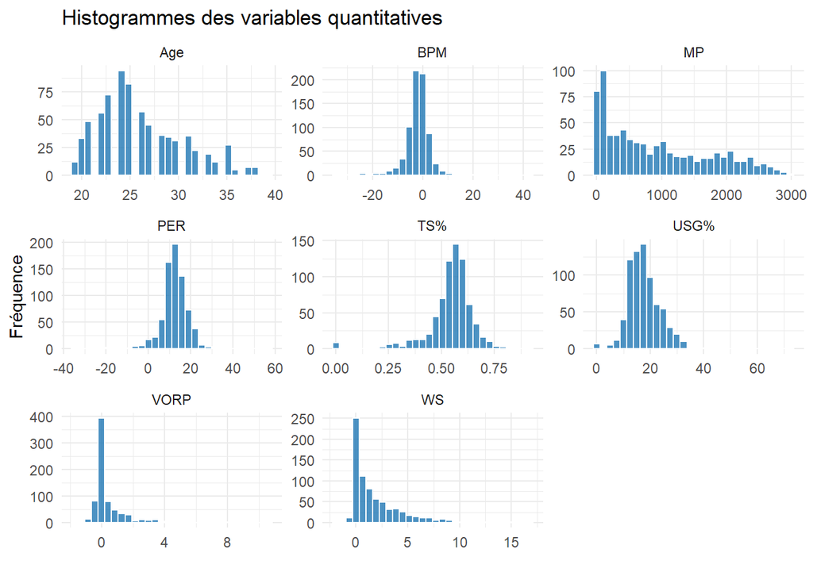

```r
#install.packages("ggplot2")
library(ggplot2)
#install.packages("tidyr")
library(tidyr)
#install.packages("dplyr")
library(dplyr)

# Liste des variables quantitatives
quant_vars <- c("Age", "PER", "TS%", "USG%", "WS", "VORP", "BPM", "MP")

# Transformer les données en format long pour ggplot
# S'assurer que les colonnes sont numériques
data <- data %>%
  mutate(across(all_of(quant_vars), ~as.numeric(.)))

# Transformer en format long pour ggplot
data_long <- data %>%
  select(all_of(quant_vars)) %>%
  pivot_longer(cols = everything(), names_to = "Variable", values_to = "Valeur")

# Histogrammes
ggplot(data_long, aes(x = Valeur)) +
  geom_histogram(bins = 30, fill = "#1f77b4", color = "white", alpha = 0.8) +
  facet_wrap(~Variable, scales = "free", ncol = 3) +
  theme_minimal() +
  labs(title = "Histogrammes des variables quantitatives", x = "", y = "Fréquence")
```

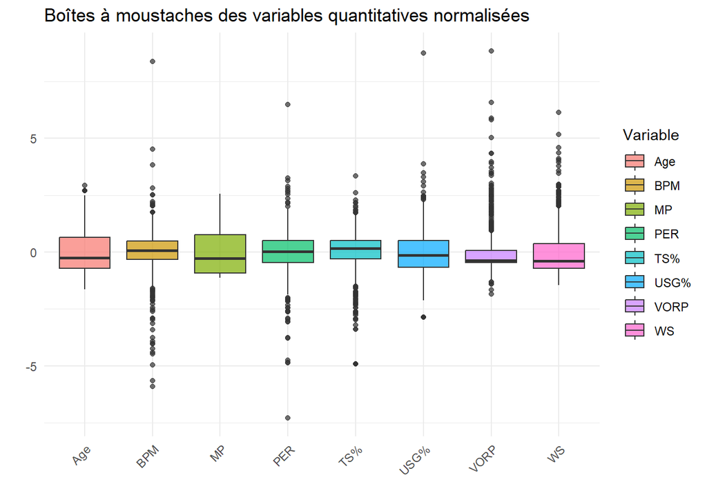

```r
# Boîtes à moustaches avec outliers visibles
# Normalisation des données (standardisation)
data_long_norm <- data_long %>%
  group_by(Variable) %>%
  mutate(Valeur = scale(Valeur)) %>%
  ungroup()
# Graphique avec boxplot après normalisation
ggplot(data_long_norm, aes(x = Variable, y = Valeur, fill = Variable)) +
  geom_boxplot(alpha = 0.7) +
  theme_minimal() +
  theme(axis.text.x = element_text(angle = 45, hjust = 1)) +
  labs(title = "Boîtes à moustaches des variables quantitatives normalisées", x = "", y = "")
```

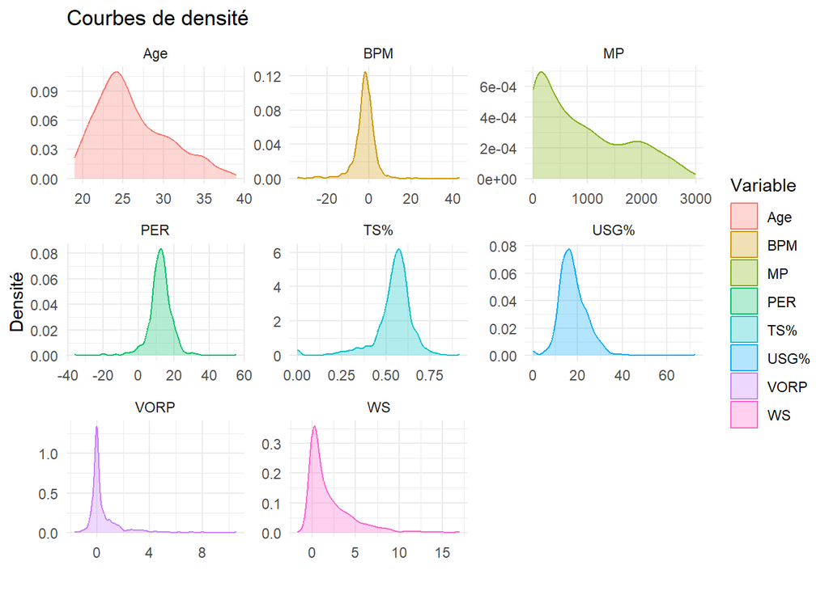

```r
# Courbes de densité
ggplot(data_long, aes(x = Valeur, color = Variable, fill = Variable)) +
  geom_density(alpha = 0.3) +
  facet_wrap(~Variable, scales = "free", ncol = 3) +
  theme_minimal() +
  labs(title = "Courbes de densité", x = "", y = "Densité")
```

*Interprétation des histogrammes :*

-**USG% (Usage Percentage)** : Distribution asymétrique à droite, la majorité des joueurs ayant un usage entre 15 et 25 %.

-**VORP (Value Over Replacement Player) et WS (Win Shares)** : Distribution fortement biaisée à droite, dominée par de petites valeurs, ce qui indique que la plupart des joueurs ont un faible impact.

*Lecture générale :*

Plusieurs variables montrent une distribution asymétrique avec une concentration de petites valeurs, sauf pour **TS%** et **PER**, qui présentent une forme plus “normale”.

*Interprétation des Boîtes à moustaches :*

**-BPM** et **VORP**

- Médianes proches de **0** (données normalisées).
- **Dispersion importante** : présence de valeurs extrêmes positives/négatives, reflétant des écarts majeurs entre joueurs moyens et stars.

**-TS% (Efficacité de tir)**

- **Distribution resserrée** : la plupart des joueurs ont des performances similaires.
- **Outliers bas** : quelques tireurs très inefficaces.

**-USG% (Taux d’utilisation)**

- **Queue de distribution étendue vers le haut** : quelques joueurs dominants offensivement (stars).

*Normalisation :*

Les données sont centrées-réduites (moyenne = 0, écart-type = 1). Ainsi : - Une valeur de **+2** dans `WS` signifie “2 écarts-types au-dessus de la moyenne”.

*Conclusions :*

### *5.3 Analyse des Variables Qualitatives*

L’analyse des variables qualitatives constitue une étape essentielle pour comprendre la structure et la composition de notre ensemble de données NBA. Cette analyse se concentre sur les trois principales variables catégorielles de notre étude : la position des joueurs, leur appartenance à une équipe et leur groupe d’âge.

Nous réalisons :

Des tableaux de fréquence absolue et relative Des diagrammes en barres ou circulaires pour visualiser la répartition Une analyse de la répartition des joueurs selon ces catégories

#### *5.3.1. Tableaux de fréquence absolue et relative*

Nous commençons par créer des tableaux de fréquence pour la variable **Position et Team, Groupe D’age**.

```r
# Tableau de fréquence absolue pour la variable Position
table_position <- table(data$Pos)
table_position
```

```
##
##   C  PF  PG  SF  SG
## 119 153 146 157 160
```

```r
# Tableau de fréquence relative pour la variable Position
prop_position <- prop.table(table(data$Pos)) * 100
prop_position
```

```
##
##        C       PF       PG       SF       SG
## 16.19048 20.81633 19.86395 21.36054 21.76871
```

```r
# Tableau de fréquence absolue pour la variable Équipe
table_team <- table(data$Team)
table_team
```

```
##
## 2TM 3TM ATL BOS BRK CHI CHO CLE DAL DEN DET GSW HOU IND LAC LAL MEM MIA MIL MIN
##  71   7  19  19  21  18  26  18  22  17  31  18  17  22  21  21  33  21  21  19
## NOP NYK OKC ORL PHI PHO POR SAC SAS TOR UTA WAS
##  20  26  22  18  28  22  22  20  20  30  21  24
```

```r
# Tableau de fréquence relative pour la variable Équipe
prop_team <- prop.table(table(data$Team)) * 100
prop_team
```

```
##
##      2TM      3TM      ATL      BOS      BRK      CHI      CHO      CLE
## 9.659864 0.952381 2.585034 2.585034 2.857143 2.448980 3.537415 2.448980
##      DAL      DEN      DET      GSW      HOU      IND      LAC      LAL
## 2.993197 2.312925 4.217687 2.448980 2.312925 2.993197 2.857143 2.857143
##      MEM      MIA      MIL      MIN      NOP      NYK      OKC      ORL
## 4.489796 2.857143 2.857143 2.585034 2.721088 3.537415 2.993197 2.448980
##      PHI      PHO      POR      SAC      SAS      TOR      UTA      WAS
## 3.809524 2.993197 2.993197 2.721088 2.721088 4.081633 2.857143 3.265306
```

```r
# Tableau de fréquence absolue pour le Groupe d'âge
table_age_group <- table(data$AgeGroup)
table_age_group
```

```
##
## Expérimenté       Jeune       Moyen
##         245         245         245
```

```r
# Tableau de fréquence relative pour le Groupe d'âge
prop_age_group <- prop.table(table(data$AgeGroup)) * 100
prop_age_group
```

```
##
## Expérimenté       Jeune       Moyen
##    33.33333    33.33333    33.33333
```

*Interprétation des résultats*

*Analyse du variable Position*

1. **Concentration autour des positions SG, SF, et PF**

Les positions **SG (Shooting Guard)**, **SF (Small Forward)**, et **PF (Power Forward)** sont les plus représentées dans cet échantillon, avec chacune représentant environ **20 à 21 %** des joueurs. Cela reflète la répartition courante des joueurs dans ces positions, qui sont souvent clés dans les dynamiques offensives et défensives des équipes de basketball.

2. **Position moins représentée - C (Center)**

La position **C (Center)** est la moins représentée, avec seulement **16.19 %** des joueurs occupant ce poste. Cela peut s’expliquer par la tendance actuelle dans le basketball moderne à avoir moins de joueurs centrés uniquement sur le poste de pivot, le jeu s’orientant davantage vers des joueurs plus polyvalents capables de jouer plusieurs rôles.

3. **Distribution relativement équilibrée**

Les positions **PF**, **PG**, **SF**, et **SG** sont assez équilibrées, avec des différences faibles dans les proportions relatives (environ **20 %** pour chacune), ce qui suggère une distribution relativement homogène de ces positions parmi les joueurs.

4. **Conclusions et perspectives**

Ces résultats peuvent être utilisés pour observer les tendances actuelles du basketball. Par exemple, les positions **SG** et **SF** ayant la plus grande proportion peuvent refléter l’accent mis sur des joueurs polyvalents, capables de jouer à la fois en attaque et en défense, et souvent plus agiles.

Une analyse plus approfondie pourrait inclure des facteurs comme l’âge ou les performances des joueurs dans ces positions pour observer si certaines positions sont favorisées par des joueurs plus jeunes ou plus expérimentés.

*Analyse du variable Team*

**1. Concentration autour des équipes les plus représentées**

**2. Les joueurs qui sont participés pour 2,3 équipes moins représentées - 3TM et 2TM**

**3. Répartition relativement équilibrée des autres équipes**

Les autres équipes sont relativement bien représentées avec des fréquences comprises entre **2 % et 4 %** pour la majorité des franchises, telles que **PHI** (Philadelphia 76ers), **MEM** (Memphis Grizzlies), **SAS** (San Antonio Spurs), et **NOP** (New Orleans Pelicans). Cela montre une certaine homogénéité dans la répartition des joueurs au sein des équipes, bien que certaines franchises soient plus dominantes.

**4. Conclusions et perspectives pour l’analyse des équipes**

Une étude plus approfondie pourrait également inclure des facteurs tels que la performance des joueurs, l’âge moyen des membres de l’équipe, et les stratégies des équipes pour observer s’il existe des différences notables en termes de performance selon l’équipe.

*Analyse du variable AgeGroup*

**1. Répartition des groupes d’âge : Un échantillon équilibré**

Les groupes d’âge **Expérimenté**, **Jeune**, et **Moyen** sont répartis de manière parfaitement équilibrée, chaque groupe représentant **33.33 %** de l’échantillon, avec **245 joueurs** dans chaque catégorie. Cela montre une volonté d’équilibrer l’expérience au sein de cet échantillon, permettant ainsi une analyse complète de la performance des joueurs en fonction de leur groupe d’âge.

**2. Répartition égale des groupes d’âge**

L’égal partage des joueurs entre ces trois groupes d’âge peut être particulièrement utile pour analyser l’impact de l’expérience et de la jeunesse sur les performances des joueurs. Par exemple, les joueurs **Expérimentés** peuvent avoir des compétences de leadership et une meilleure compréhension tactique, tandis que les joueurs **Jeunes** peuvent avoir plus d’énergie et de potentiel de développement. Le groupe **Moyen** pourrait inclure des joueurs au sommet de leur carrière.

**3. Conclusions et perspectives pour l’analyse des groupes d’âge**

La répartition égale des groupes d’âge permet de mener une analyse comparative robuste, notamment en examinant l’impact de l’âge sur les performances des joueurs. On pourrait explorer si les joueurs plus jeunes sont plus souvent impliqués dans des équipes avec des stratégies offensives plus agressives, ou si les joueurs plus expérimentés sont privilégiés pour des rôles de mentorat ou de leadership dans les équipes.

Cela pourrait aussi être intéressant de croiser ces informations avec des variables de performance (comme **PER**, **BPM**, etc.) pour voir si les joueurs jeunes, moyens ou expérimentés ont des profils de performance différents.

**Conclusion générale:**

Les analyses des variables **Équipe** et **Groupe d’âge**et **Position** mettent en lumière des tendances importantes dans la répartition des joueurs. La répartition des joueurs entre les équipes varie, avec certaines équipes sur-représentées, et d’autres sous-représentées. De même, la répartition équilibrée des groupes d’âge permet de comparer les performances des joueurs selon leur expérience. Ces résultats pourraient être exploités pour des analyses approfondies sur les stratégies d’équipe, la performance en fonction de l’âge, et la composition des effectifs dans la NBA.

#### *5.3.2.Diagrammes en barres et circulaires*

Les variables catégorielles permettent de regrouper les individus par catégories distinctes. Ici, nous allons visualiser les variables Position, Team et AgeGroup à l’aide de :

```
**-Diagrammes en barres (fréquences absolues et relatives)**

**-Diagrammes circulaires (fréquences absolues et relatives)**
```

##### *a) Diagramme en barres pour les variables catégorielles*

Les diagrammes en barres permettent de représenter visuellement la fréquence ou la proportion de chaque modalité d’une variable catégorielle.

Ci-dessous, nous présentons à la fois les fréquences absolues et relatives pour les variables Position, Team et AgeGroup.

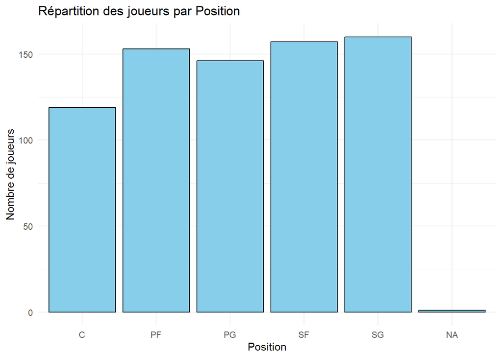

```r
#  Chargement des packages nécessaires
library(ggplot2)
#install.packages("scales")
library(scales)
#install.packages("patchwork")
library(patchwork)  # Pour l'agencement côte à côte

#  Diagrammes en barres - Fréquences absolues

## Position
ggplot(data, aes(x = Pos)) +
  geom_bar(fill = "skyblue", color = "black") +
  theme_minimal() +
  labs(title = "Répartition des joueurs par Position", x = "Position", y = "Nombre de joueurs")
```

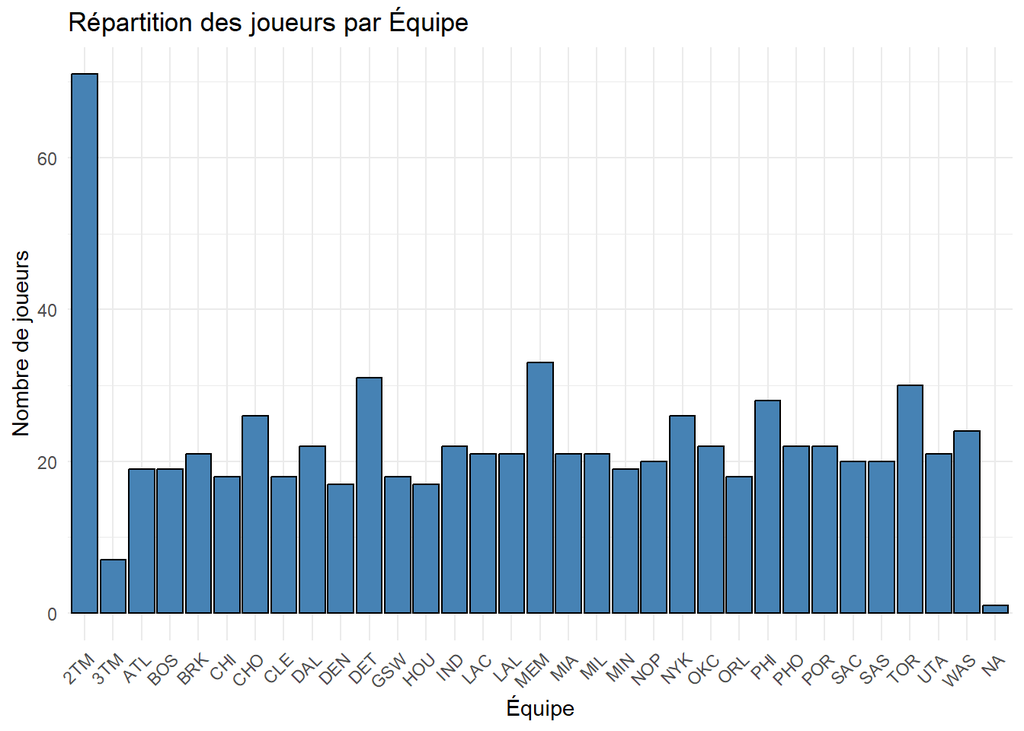

```r
## Team
ggplot(data, aes(x = Team)) +
  geom_bar(fill = "steelblue", color = "black") +
  theme_minimal() +
  theme(axis.text.x = element_text(angle = 45, hjust = 1)) +
  labs(title = "Répartition des joueurs par Équipe", x = "Équipe", y = "Nombre de joueurs")
```

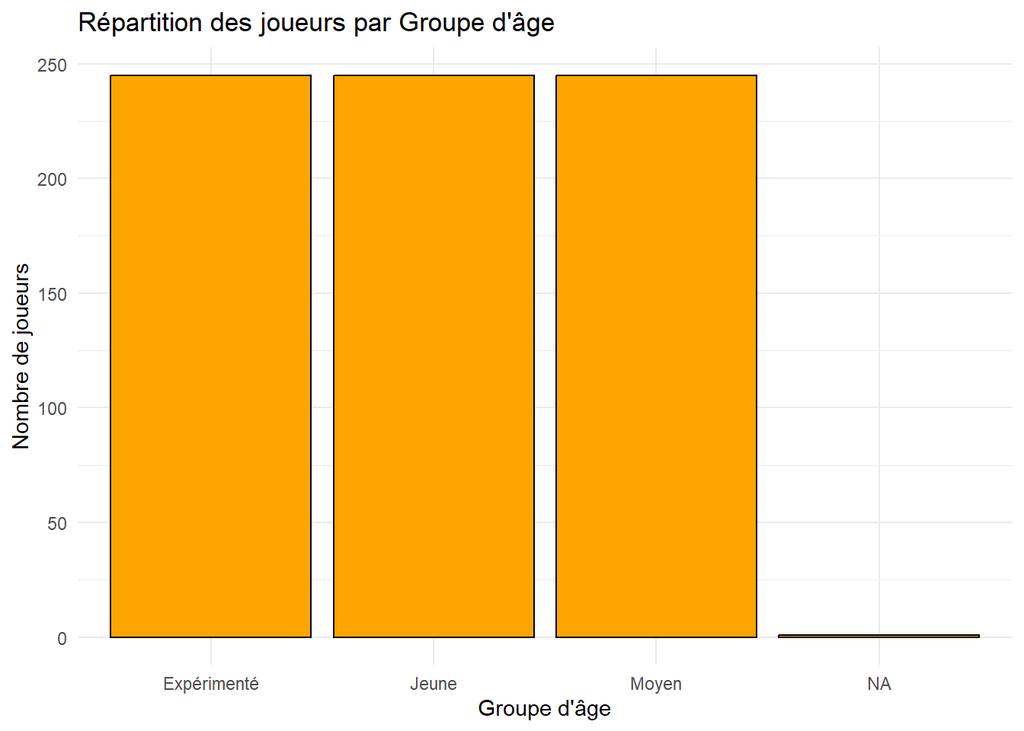

```r
## AgeGroup
ggplot(data, aes(x = AgeGroup)) +
  geom_bar(fill = "orange", color = "black") +
  theme_minimal() +
  labs(title = "Répartition des joueurs par Groupe d'âge", x = "Groupe d'âge", y = "Nombre de joueurs")
```

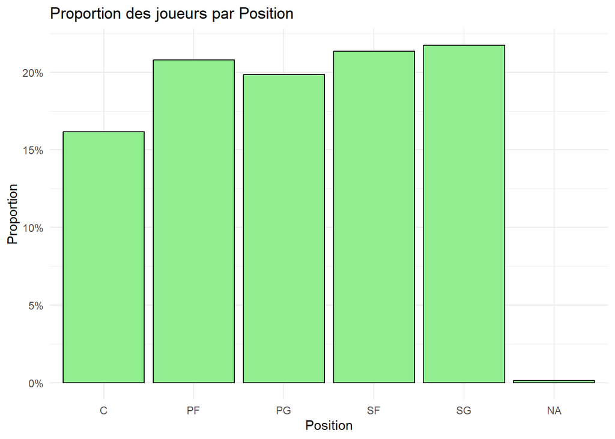

```r
#  Diagrammes en barres - Fréquences relatives

## Position
ggplot(data, aes(x = Pos)) +
  geom_bar(aes(y = (..count..) / sum(..count..)), fill = "lightgreen", color = "black") +
  theme_minimal() +
  labs(title = "Proportion des joueurs par Position", x = "Position", y = "Proportion") +
  scale_y_continuous(labels = percent)
```

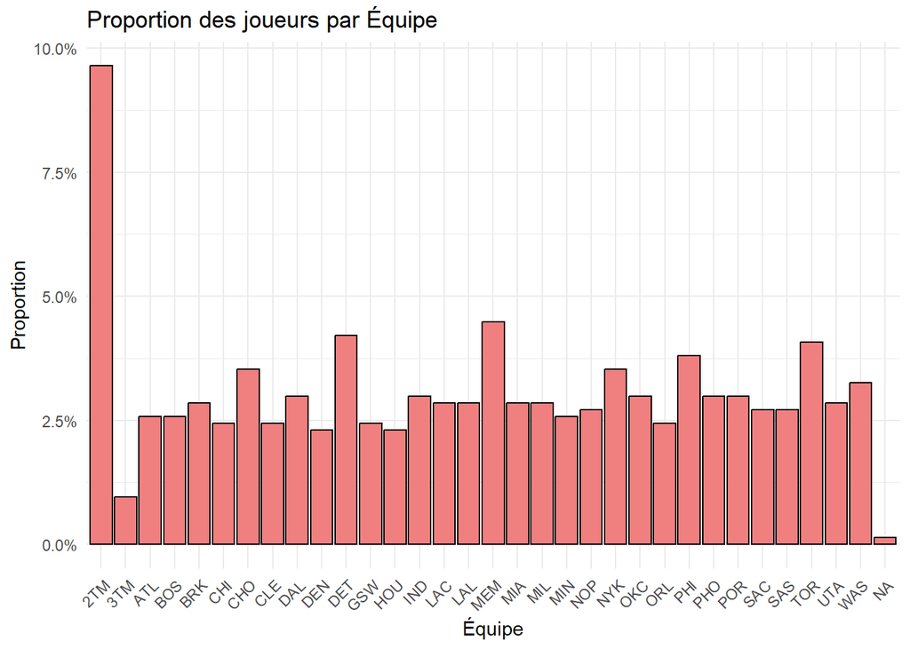

```r
## Team
ggplot(data, aes(x = Team)) +
  geom_bar(aes(y = (..count..) / sum(..count..)), fill = "lightcoral", color = "black") +
  theme_minimal() +
  theme(axis.text.x = element_text(angle = 45, hjust = 1)) +
  labs(title = "Proportion des joueurs par Équipe", x = "Équipe", y = "Proportion") +
  scale_y_continuous(labels = percent)
```

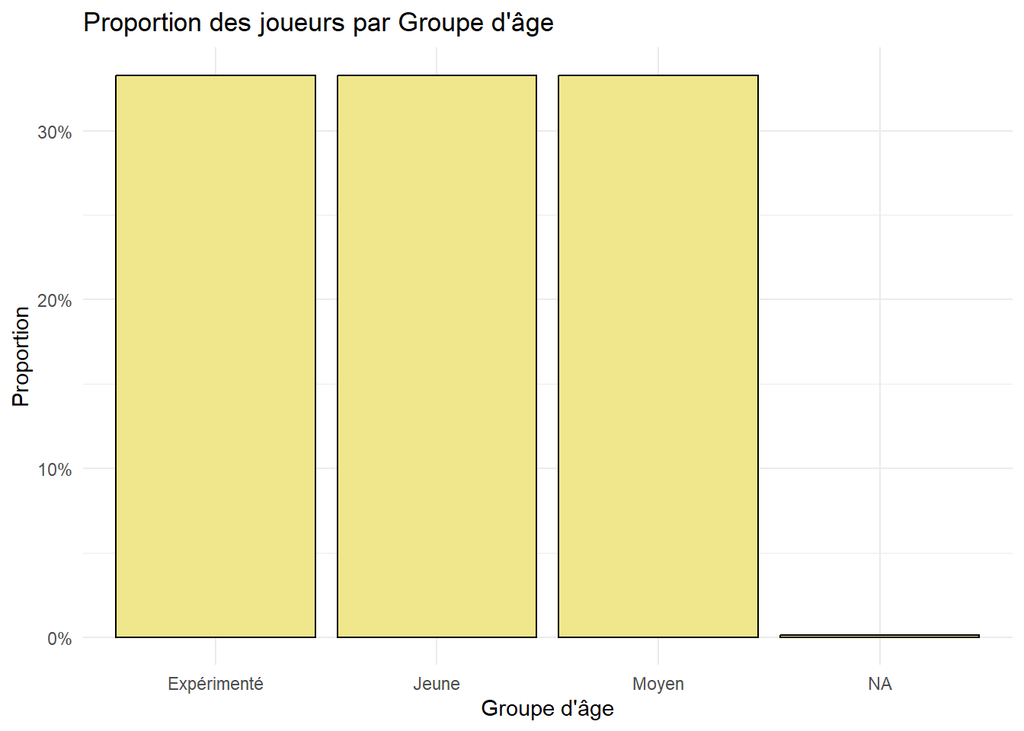

```r
## AgeGroup
ggplot(data, aes(x = AgeGroup)) +
  geom_bar(aes(y = (..count..) / sum(..count..)), fill = "khaki", color = "black") +
  theme_minimal() +
  labs(title = "Proportion des joueurs par Groupe d'âge", x = "Groupe d'âge", y = "Proportion") +
  scale_y_continuous(labels = percent)
```

Analyse détaillée des fréquences absolues et relatives

**Répartition des joueurs par Position**

**Répartition des joueurs par Équipe**

**Proportion des joueurs par Groupe d’âge**

Dans l’ensemble, l’analyse des fréquences absolues et relatives des variables **Position**, **Équipe** et **AgeGroup** met en lumière plusieurs tendances importantes :

Cette analyse fournit des **insights précieux** pour comprendre la structure et la dynamique des équipes sportives étudiées, offrant ainsi des **pistes intéressantes** pour des recherches futures ou des **ajustements stratégiques**.

##### *b) Diagrammes circulaires (Pie charts) pour les variables catégorielles*

Les diagrammes circulaires permettent de représenter la répartition des catégories d’une variable en proportion du total. Ils sont souvent utilisés lorsque le nombre de catégories est limité.

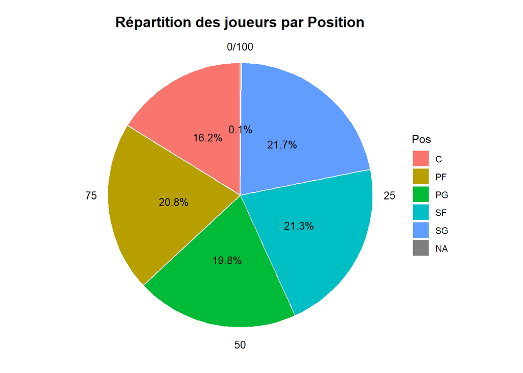

```r
library(ggplot2)
library(dplyr)
library(patchwork)

# Fonction de création des graphiques en camembert avec gestion des couleurs et des marges
make_pie_chart <- function(data, varname, title = NULL) {
  # Récupérer les données
  var_data <- data %>% count({{ varname }}) %>%
    mutate(perc = n / sum(n) * 100,
           label = paste0(round(perc, 1), "%"))

  # Palette dynamique en fonction du nombre de catégories
  nb_colors <- n_distinct(pull(var_data, {{ varname }}))
  colors <- hcl(h = seq(15, 375, length = nb_colors + 1), l = 65, c = 100)[1:nb_colors]

  # Tracer le camembert avec ajustements
  ggplot(var_data, aes(x = "", y = perc, fill = factor({{ varname }}))) +
    geom_bar(stat = "identity", width = 1, color = "white") +
    coord_polar("y", start = 0) +
    geom_text(aes(label = label), position = position_stack(vjust = 0.5), size = 3.5) +
    scale_fill_manual(values = colors) +
    labs(title = title, fill = as_label(enquo(varname))) +
    theme_void() +
    theme(
      legend.position = "right",
      plot.title = element_text(hjust = 0.5, face = "bold", size = 14),
      axis.text = element_text(size = 10),  # Ajuster la taille du texte des axes
      axis.title = element_blank(),  # Enlever les titres d'axes
      plot.margin = margin(10, 10, 10, 10)  # Ajuster les marges autour du graphique
    )
}

# Supposons que p1, p2 et p3 sont tes graphiques
p1 <- make_pie_chart(data, Pos, title = "Répartition des joueurs par Position")
p1
```

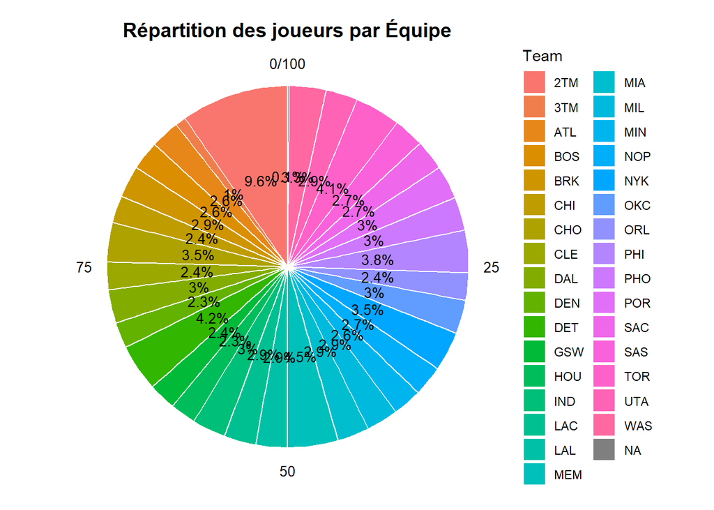

```r
p2 <- make_pie_chart(data, Team, title = "Répartition des joueurs par Équipe")
p2
```

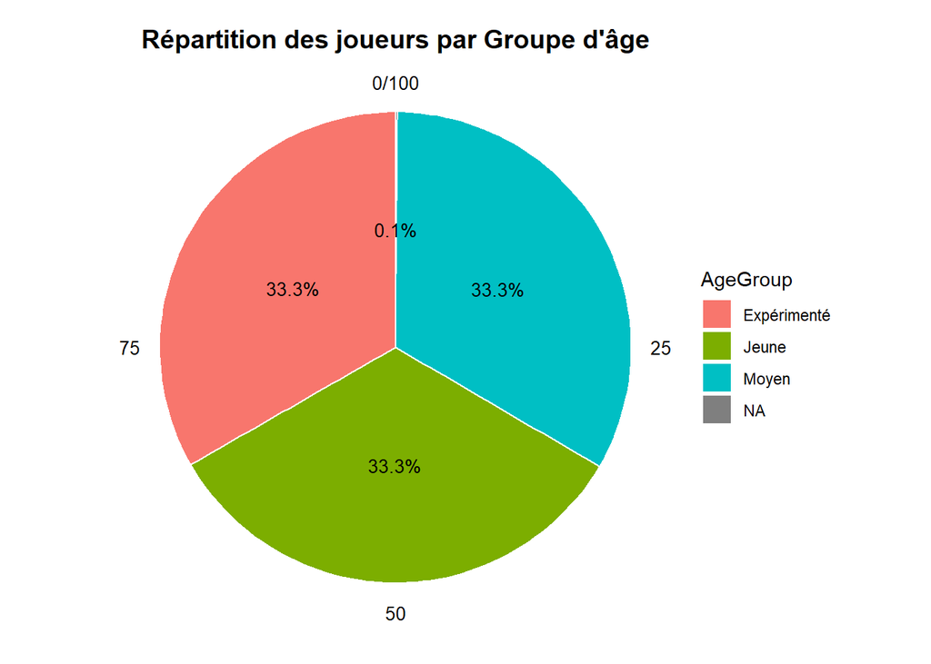

```r
p3 <- make_pie_chart(data, AgeGroup, title = "Répartition des joueurs par Groupe d'âge")
p3
```

Interprétation détaillée des diagrammes circulaires

1. Répartition des joueurs par Position

2. Répartition des joueurs par Groupe d’âge

**Fréquences relatives** :  
- Expérimenté : 33.3%  
- Jeune : 33.3%  
- Moyen : 33.3%  
- NA : 0.1%

**Interprétation** :  
La répartition est **parfaitement équilibrée** entre les trois groupes d’âge.  
La catégorie **NA est marginale**, ce qui montre que les données sur l’âge sont quasi complètes.

3. Répartition des joueurs par Équipe

### *5.4 Transformation des Variables*

Suite à l’analyse univariée, certaines variables nécessitent des transformations pour améliorer leur normalité ou leur interprétabilité, avant de les utiliser dans les analyses multivariées. Les transformations visent à rendre les distributions des variables plus symétriques, à les rendre comparables entre elles et à mieux refléter les relations entre les variables. Nous allons procéder à trois types principaux de transformations : la **transformation logarithmique**, la **standardisation et la normalisation**.

#### *5.4.1 Transformation Logarithmique*

Certaines variables peuvent présenter une distribution fortement asymétrique, notamment les variables mesurant l’efficacité ou le taux d’utilisation d’un joueur. Pour normaliser ces distributions et améliorer leur analyse, nous appliquons une transformation logarithmique.

**Objectif**

La transformation logarithmique est appliquée pour réduire l’asymétrie positive et rendre les variables plus proches d’une distribution normale, ce qui est souvent un prérequis pour de nombreux tests statistiques

```r
# Transformation logarithmique de certaines variables

# Vérification du type de la colonne PER
str(data$PER)
```

```
##  num [1:736] 19.7 23.2 14.5 14.9 17.3 21.2 17.7 19.7 31 23.4 ...
```

```r
# Conversion en numérique si nécessaire
if (!is.numeric(data$PER)) {
  data$PER <- as.numeric(as.character(data$PER))
}

# Gestion des valeurs manquantes (NA) : remplacement par 0 ou une autre valeur pertinente
data$PER[is.na(data$PER)] <- 0

# Vérification des valeurs négatives dans PER
sum(data$PER < 0)  # Affiche le nombre de valeurs négatives
```

```
## [1] 22
```

```r
data$PER[data$PER < 0] <- 0  # Remplace les valeurs négatives par 0

# Transformation logarithmique de PER (ajout de 1 pour éviter log(0))
data$log_PER <- log(data$PER + 1)

# Vérification des NaN dans log_PER
sum(is.nan(data$log_PER))  # Affiche le nombre de NaN dans la variable log_PER
```

```
## [1] 0
```

```r
# Afficher les premières valeurs de log_PER
head(data$log_PER)
```

```
## [1] 3.030134 3.186353 2.740840 2.766319 2.906901 3.100092
```

```r
# Vérification du type de la colonne USG%
str(data$`USG%`)
```

```
##  num [1:736] 25.8 22.2 22.7 24.3 29.7 29 26.6 32.3 29.3 32.5 ...
```

```r
# Conversion en numérique si nécessaire pour la colonne USG%
if (!is.numeric(data$`USG%`)) {
  data$`USG%` <- as.numeric(as.character(data$`USG%`))
}

# Gestion des valeurs manquantes (NA) pour USG% : remplacement par 0 ou une autre valeur pertinente
data$`USG%`[is.na(data$`USG%`)] <- 0

# Vérification des valeurs négatives dans USG%
sum(data$`USG%` < 0)  # Affiche le nombre de valeurs négatives
```

```
## [1] 0
```

```r
data$`USG%`[data$`USG%` < 0] <- 0  # Remplace les valeurs négatives par 0

# Transformation logarithmique de USG% (ajout de 1 pour éviter log(0))
data$log_USG <- log(data$`USG%` + 1)

# Vérification des NaN dans log_USG
sum(is.nan(data$log_USG))  # Affiche le nombre de NaN dans la variable log_USG
```

```
## [1] 0
```

```r
# Afficher les premières valeurs de log_USG
head(data$log_USG)
```

```
## [1] 3.288402 3.144152 3.165475 3.230804 3.424263 3.401197
```

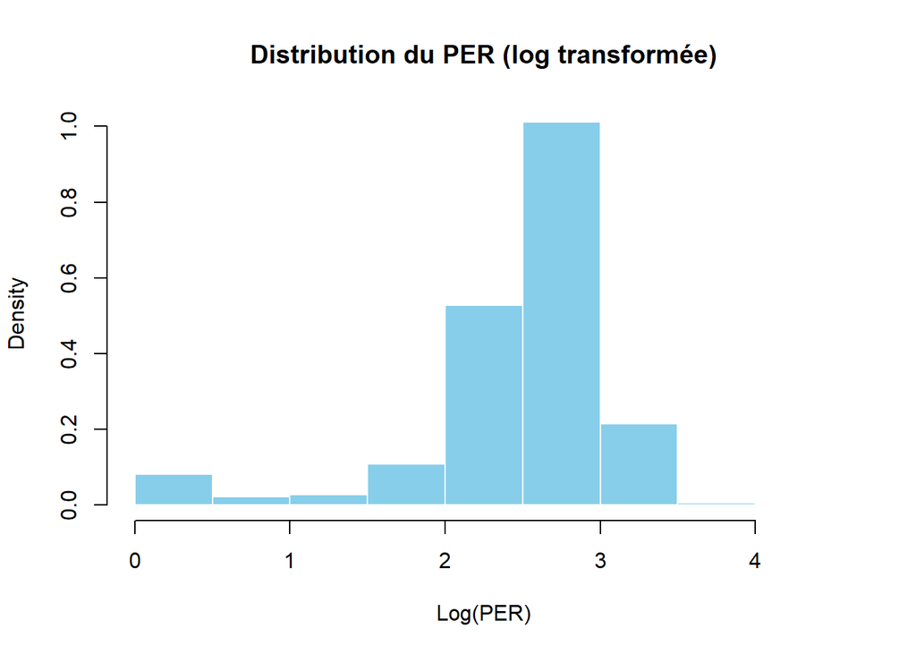

```r
# Vérification de la transformation

# Configuration de l'affichage des graphiques côte à côte
par(mar = c(5, 4, 4, 2) + 0.1)  # Augmenter l'espace en haut du graphique pour les titres

# Histogramme avec courbe de densité pour log_PER
hist(data$log_PER,
     main = "Distribution du PER (log transformée)",
     xlab = "Log(PER)",
     col = "skyblue",
     border = "white",
     probability = TRUE)  # Echelle de densité
```

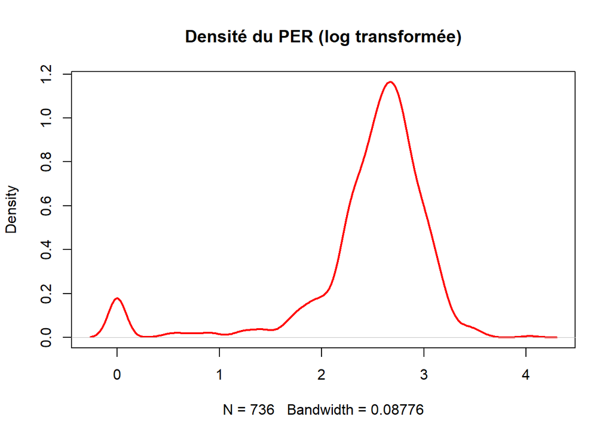

```r
# Tracer directement la densité sur l'histogramme
density_log_per <- density(data$log_PER, na.rm = TRUE)

plot(density_log_per, col = "red", lwd = 2,main="Densité du PER (log transformée)")  # `add = TRUE` pour ajouter sur l'histogramme
```

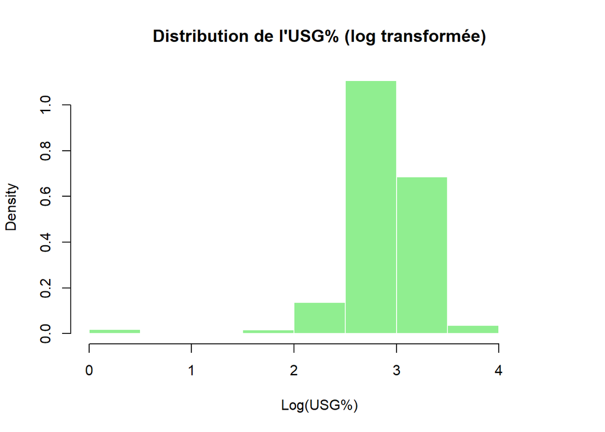

```r
# Histogramme avec courbe de densité pour log_USG
hist(data$log_USG,
     main = "Distribution de l'USG% (log transformée)",
     xlab = "Log(USG%)",
     col = "lightgreen",
     border = "white",
     probability = TRUE)  # Echelle de densité
```

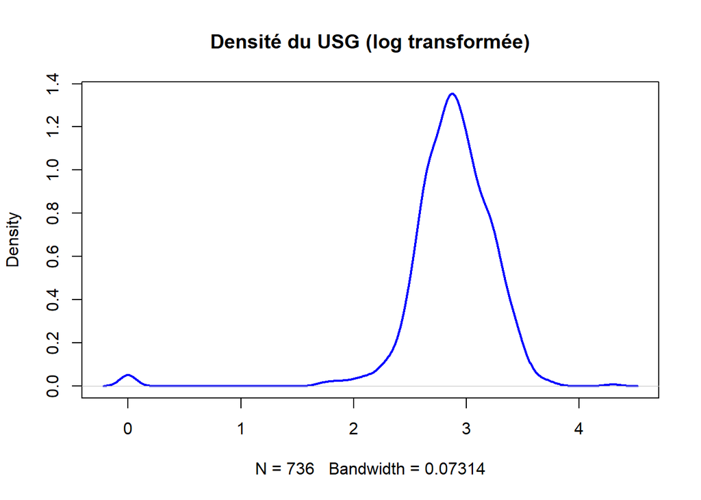

```r
# Tracer directement la densité sur l'histogramme
density_log_usg <- density(data$log_USG, na.rm = TRUE)
plot(density_log_usg, col = "blue",main="Densité du USG (log transformée)", lwd = 2)  # `add = TRUE` pour ajouter sur l'histogramme
```

**Analyse des Distributions Logarithmiques de l’USG% et du PER**

Les graphiques Ci-dessus présentent les distributions transformées logarithmiquement de l’USG% (Taux d’Utilisation) et du PER (Player Efficiency Rating) pour **736 joueurs**, offrant des perspectives analytiques précieuses.

Ces données se prêtent particulièrement bien à des analyses avancées telles que :

- Le **clustering** pour segmenter les joueurs selon leur usage et efficacité.
- L’étude des **corrélations entre USG% et PER**.
- L’identification des profils extrêmes via des méthodes statistiques.

Ces métriques offrent ainsi une base solide pour explorer les dynamiques de performance individuelles en basketball, depuis des approches descriptives jusqu’à des modélisations prédictives plus complexes.

#### *5.4.2 Standardisation et Normalisation*

Les variables quantitatives telles que **TS%**, **BPM** et **VORP** peuvent présenter des échelles et des unités différentes. Pour les rendre comparables, nous appliquons des techniques de standardisation ou de normalisation.

**Objectif**

La standardisation (moyenne = 0, écart-type = 1) permet de rendre les variables comparables, ce qui est essentiel lors de l’utilisation de techniques multivariées, telles que les régressions ou les modèles de classification.

```r
# Vérification et nettoyage de la colonne TS%
# Enlever les caractères non numériques comme "%" et convertir en numérique si nécessaire
data$`TS%` <- as.numeric(gsub("%", "", data$`TS%`))

# Vérification de la conversion
str(data$`TS%`)
```

```
##  num [1:736] 0.584 0.637 0.57 0.56 0.546 0.626 0.555 0.575 0.65 0.592 ...
```

```r
# Remplacer les valeurs NA par 0 ou une autre valeur pertinente
data$`TS%`[is.na(data$`TS%`)] <- 0

# Standardisation de la variable TS%
data$std_TS <- scale(data$`TS%`)

# Vérification de la standardisation
summary(data$std_TS)
```

```
##        V1
##  Min.   :-4.3407
##  1st Qu.:-0.2294
##  Median : 0.1777
##  Mean   : 0.0000
##  3rd Qu.: 0.4982
##  Max.   : 3.0516
```

```r
# Vérification et nettoyage de la colonne BPM (si nécessaire)
# Assurer que BPM est bien numérique
data$BPM <- as.numeric(data$BPM)

# Remplacer les valeurs NA par 0 ou une autre valeur pertinente dans BPM
data$BPM[is.na(data$BPM)] <- 0

# Standardisation de la variable BPM
data$std_BPM <- scale(data$BPM)

# Vérification de la standardisation
summary(data$std_BPM)
```

```
##        V1
##  Min.   :-5.89699
##  1st Qu.:-0.32753
##  Median : 0.07954
##  Mean   : 0.00000
##  3rd Qu.: 0.48661
##  Max.   : 8.38748
```

```r
# Vérification et nettoyage de la colonne VORP (si nécessaire)
# Assurer que VORP est bien numérique
data$VORP <- as.numeric(data$VORP)

# Remplacer les valeurs NA par 0 ou une autre valeur pertinente dans VORP
data$VORP[is.na(data$VORP)] <- 0

# Standardisation de la variable VORP
data$std_VORP <- scale(data$VORP)

# Vérification de la standardisation
summary(data$std_VORP)
```

```
##        V1
##  Min.   :-1.84176
##  1st Qu.:-0.45138
##  Median :-0.36448
##  Mean   : 0.00000
##  3rd Qu.: 0.07001
##  Max.   : 8.84678
```

**Standardisation et Normalisation des Variables de Performance**

L’analyse présente les résultats des opérations de **standardisation** et de **normalisation** effectuées sur trois variables clés pour l’évaluation des performances des joueurs de basketball : le **TS%** (True Shooting Percentage), le **BPM** (Box Plus-Minus) et le **VORP** (Value Over Replacement Player).

Pour le **TS%**, les valeurs initialement exprimées en pourcentage ont été nettoyées en supprimant le symbole “%” avant d’effectuer une conversion en format numérique. Ensuite, les valeurs manquantes ont été remplacées par 0, une approche pragmatique permettant de conserver l’intégralité des joueurs dans l’analyse. Cependant, cette approche pourrait introduire un biais, notamment dans les cas où l’absence de données reflète une non-participation plutôt qu’une performance nulle. La **standardisation** de cette variable a permis d’observer une distribution où la médiane (0.1777) est légèrement supérieure à la moyenne (0), indiquant une légère asymétrie. Les valeurs extrêmes, allant de -4.34 pour les joueurs les moins performants à 3.05 pour les joueurs les plus efficaces, montrent une variation importante autour de la moyenne.

Pour le **BPM** et le **VORP**, un traitement similaire a été appliqué. Après standardisation, les distributions de ces deux variables montrent des étendues plus larges. En particulier pour le **VORP**, l’écart entre les valeurs minimales (-1.84) et maximales (8.85) est significatif, mettant en évidence la présence de joueurs exceptionnellement performants comparés à la moyenne.

Ces transformations standardisées, en ramenant toutes les variables à une échelle commune avec une moyenne de 0 et un écart-type de 1, permettent de faciliter les comparaisons entre différentes métriques. De plus, elles préparent le terrain pour des analyses multivariées ou des algorithmes de machine learning, qui sont souvent sensibles à l’échelle des données.

## **6.Analyse Bivariée des Données**

L’analyse bivariée constitue une étape cruciale dans notre exploration des statistiques NBA, permettant d’examiner les relations entre paires de variables et d’identifier des patterns significatifs qui pourraient orienter nos stratégies d’optimisation d’équipe.

### *6.1 Méthodologie*

Notre approche combine plusieurs techniques complémentaires afin d’analyser les relations entre les variables et de tester nos hypothèses. Ces techniques incluent :

-Matrices de corrélation pour quantifier les relations linéaires entre variables quantitatives

-Tests statistiques appropriés selon la nature des variables (t-test, ANOVA, chi-carré)

-Visualisations adaptées pour illustrer ces relations (nuages de points, boîtes à moustaches)

### *6.2. Matrices de Corrélation des Variables Quantitatives*

Les matrices de corrélation sont utilisées pour quantifier les relations linéaires entre plusieurs variables quantitatives. Elles permettent de déterminer la force et la direction de l’association entre chaque paire de variables, facilitant ainsi l’identification de redondances ou de dépendances significatives.

Pour quantifier les relations linéaires entre ces variables quantitatives, nous utilisons la fonction `cor()` en R. Cette fonction calcule le coefficient de corrélation de Pearson entre chaque paire de variables, ce qui permet de comprendre à quel point elles sont liées linéairement.

```r
# Assurez-vous que toutes les variables sont numériques
quantitative_vars <- data[, c("Age", "PER", "TS%", "USG%", "WS", "VORP", "BPM", "MP")]

# Conversion des variables en numériques si nécessaire
quantitative_vars[] <- lapply(quantitative_vars, function(x) as.numeric(as.character(x)))

# Vérification du type de chaque colonne
sapply(quantitative_vars, class)
```

```
##       Age       PER       TS%      USG%        WS      VORP       BPM        MP
## "numeric" "numeric" "numeric" "numeric" "numeric" "numeric" "numeric" "numeric"
```

```r
# Calcul de la matrice de corrélation
cor_matrix <- cor(quantitative_vars, use = "complete.obs", method = "pearson")

# Affichage de la matrice de corrélation
cor_matrix
```

```
##              Age        PER        TS%        USG%        WS      VORP
## Age   1.00000000 0.04130371 0.08563764 -0.10483217 0.1547216 0.1384152
## PER   0.04130371 1.00000000 0.68187648  0.42743659 0.5683389 0.5717671
## TS%   0.08563764 0.68187648 1.00000000  0.11336574 0.3828945 0.2697281
## USG% -0.10483217 0.42743659 0.11336574  1.00000000 0.2979635 0.3898638
## WS    0.15472163 0.56833893 0.38289449  0.29796355 1.0000000 0.8906629
## VORP  0.13841516 0.57176714 0.26972811  0.38986382 0.8906629 1.0000000
## BPM   0.12748264 0.83765456 0.67055119  0.06676783 0.4849430 0.4806185
## MP    0.10505618 0.41146727 0.35322985  0.31663342 0.8212139 0.6035562
##             BPM        MP
## Age  0.12748264 0.1050562
## PER  0.83765456 0.4114673
## TS%  0.67055119 0.3532298
## USG% 0.06676783 0.3166334
## WS   0.48494303 0.8212139
## VORP 0.48061852 0.6035562
## BPM  1.00000000 0.3869142
## MP   0.38691418 1.0000000
```

Visualisation de la Matrice de Corrélation

Afin de mieux comprendre la structure des corrélations, nous pouvons visualiser la matrice de corrélation sous forme de carte thermique. Cette représentation visuelle facilite l’interprétation des relations linéaires entre les variables.

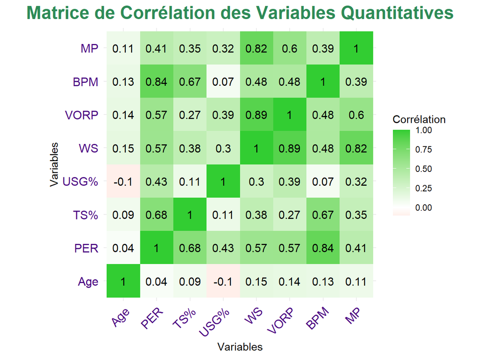

```r
# Installation et chargement du package pour la carte thermique
#install.packages("ggplot2")
#install.packages("reshape2")
library(ggplot2)
library(reshape2)
# Transformation de la matrice de corrélation en format long
melted_cor_matrix <- melt(cor_matrix)

# Carte thermique de la matrice de corrélation
ggplot(data = melted_cor_matrix, aes(Var1, Var2, fill = value)) +
  geom_tile() +
  geom_text(aes(label = round(value, 2)), color = "black", size = 4) +  # Ajout des chiffres dans les cases
  scale_fill_gradient2(low = "#FF6347", high = "#32CD32", mid = "#FFFFFF", midpoint = 0, name = "Corrélation") +  # Couleur incroyable
  theme_minimal() +
  theme(axis.text.x = element_text(angle = 45, hjust = 1, size = 12, color = "#4B0082"),  # Couleur pour les labels de l'axe X
        axis.text.y = element_text(size = 12, color = "#4B0082"),  # Couleur pour les labels de l'axe Y
        plot.title = element_text(size = 18, face = "bold", color = "#2E8B57", hjust = 0.5)) +  # Titre avec style
  labs(title = "Matrice de Corrélation des Variables Quantitatives",
       x = "Variables", y = "Variables") +
  coord_fixed()  # Assure une forme carrée pour la matrice
```

Interprétation de la Matrice de Corrélation

1. Corrélations fortes (≥ 0.7)

MP et WS (0.82)

Cette corrélation très forte indique que les joueurs qui accumulent plus de minutes de jeu (MP) ont tendance à générer davantage de Win Shares (WS). Le temps de jeu est donc un prédicteur majeur de la contribution aux victoires de l’équipe.  
**Implication** : Les entraîneurs accordent logiquement plus de temps de jeu aux joueurs qui contribuent le plus aux victoires, créant ainsi une relation bidirectionnelle. Pour toute analyse statistique des performances, il est crucial de considérer le temps de jeu comme variable de contrôle.

PER et BPM (0.84)

La forte corrélation entre le Player Efficiency Rating (PER) et le Box Plus/Minus (BPM) montre que ces deux métriques avancées, bien que calculées différemment, évaluent des aspects similaires de la performance des joueurs.  
**Implication** : L’utilisation simultanée de ces deux variables dans un modèle statistique risque de créer de la multicolinéarité. Pour éviter la redondance, il serait préférable de n’en utiliser qu’une seule selon l’objectif de l’analyse.

VORP et WS (0.89)

La corrélation la plus élevée de la matrice existe entre la Value Over Replacement Player (VORP) et les Win Shares (WS). Ces deux métriques visent à quantifier la valeur totale d’un joueur, mais par des méthodes de calcul différentes.  
**Implication** : Cette forte convergence valide la fiabilité de ces métriques comme indicateurs de la contribution globale d’un joueur. Dans un contexte analytique, l’une peut généralement se substituer à l’autre.

En plus,La relation très forte entre ces variables confirme que les joueurs qui apportent une valeur significative au-dessus d’un remplaçant moyen (VORP) contribuent également substantiellement aux victoires de leur équipe (WS).  
**Exemple** : Des joueurs comme LeBron James ou Nikola Jokić présentent systématiquement des valeurs élevées dans ces deux métriques, confirmant leur impact considérable sur le succès de leur équipe.

2. Corrélations modérées (0.4 à 0.7)

MP et VORP (0.6)

Le temps de jeu (MP) montre une corrélation modérée avec la Value Over Replacement Player (VORP), ce qui est cohérent avec la méthodologie de calcul du VORP qui intègre le temps de jeu dans son équation.  
**Implication** : Bien que le temps de jeu influence le VORP, la corrélation modérée (et non forte) suggère que la qualité de la performance pendant ces minutes reste un facteur déterminant. Un joueur avec beaucoup de minutes mais une performance médiocre n’obtiendra pas nécessairement un VORP élevé.

PER et WS (0.57)

L’efficacité individuelle (PER) est modérément corrélée avec la contribution aux victoires (WS), indiquant que l’efficacité se traduit partiellement, mais pas totalement, en victoires pour l’équipe.  
**Implication** : D’autres facteurs comme le contexte d’équipe, le rôle du joueur et la complémentarité avec les coéquipiers influencent la conversion de l’efficacité individuelle en succès collectif. Un joueur très efficace dans une équipe faible pourrait avoir un PER élevé mais des WS limités.

TS% et BPM (0.67)

L’efficacité de tir (True Shooting Percentage) présente une corrélation substantielle avec le Box Plus/Minus, confirmant l’importance cruciale de l’efficacité offensive dans l’impact global d’un joueur.  
**Implication** : Les joueurs capables de marquer efficacement tendent à avoir un impact positif sur le différentiel de points de leur équipe. Cette relation presque forte suggère que l’amélioration de l’efficacité de tir est un levier important pour augmenter la contribution globale d’un joueur.

PER et TS% (0.68)

La corrélation substantielle entre l’efficacité de tir (TS%) et le PER reflète l’importance de l’efficacité offensive dans le calcul du PER, qui récompense fortement les tirs efficaces.  
**Implication** : Pour améliorer son PER, un joueur devrait prioritairement travailler sur sa sélection de tirs et son efficacité, plutôt que d’augmenter simplement son volume de tirs.

3. Corrélations faibles ou négligeables (≤ 0.3)

Âge et autres variables (0.04 à 0.15)

L’âge présente des corrélations très faibles avec presque toutes les métriques de performance, avec une légère corrélation négative avec le taux d’utilisation USG% (-0.1).  
**Implication** : Cette quasi-absence de corrélation linéaire masque probablement une relation non-linéaire (courbe en cloche) entre l’âge et la performance. Les joueurs atteignent généralement leur apogée au milieu de leur carrière, avec des performances qui augmentent puis diminuent ensuite. Une analyse par tranche d’âge serait plus révélatrice.

USG% et TS% (0.11)

La très faible corrélation entre le taux d’utilisation (USG%) et l’efficacité de tir (TS%) contredit l’intuition selon laquelle une charge offensive plus élevée entraînerait nécessairement une baisse d’efficacité.  
**Exemple** : Des joueurs comme Kevin Durant ou Stephen Curry maintiennent une efficacité de tir exceptionnelle malgré un taux d’utilisation élevé, tandis que d’autres joueurs peuvent être inefficaces même avec un faible taux d’utilisation. Cette relation complexe mérite une analyse plus nuancée, potentiellement par position ou par style de jeu.

USG% et BPM (0.07)

La corrélation quasi nulle entre l’utilisation (USG%) et le Box Plus/Minus (BPM) est particulièrement révélatrice. Elle indique que le simple fait de posséder davantage le ballon et de terminer les possessions ne garantit pas un impact positif sur le différentiel de points.  
**Implication** : Cette dissociation entre utilisation et impact suggère l’importance de la qualité des décisions et de l’efficacité plutôt que du volume d’actions. Pour les recruteurs et analystes, cela souligne la nécessité d’évaluer comment un joueur utilise ses possessions, pas seulement combien il en utilise.

4. Focus sur USG% (Usage Percentage)

Corrélations générales (-0.1 à 0.43)

Le taux d’utilisation (USG%) présente des corrélations généralement faibles avec les autres métriques de performance, sa corrélation la plus élevée étant avec le PER (0.43).  
**Implication** : L’USG% semble capturer une dimension unique de la performance (la responsabilité offensive) qui n’est pas directement reflétée dans les métriques d’efficacité ou d’impact. Cette indépendance relative en fait une variable intéressante pour segmenter les profils de joueurs.

USG% et âge (-0.1)

La légère corrélation négative entre l’âge et le taux d’utilisation suggère que les joueurs plus âgés tendent à réduire légèrement leur charge offensive.  
**Implication** : Cette tendance pourrait refléter l’évolution du rôle des vétérans qui, avec l’expérience, compensent potentiellement la diminution de leurs capacités athlétiques par une meilleure sélection d’actions et une plus grande économie d’énergie.

5. Focus sur TS% (True Shooting Percentage)

Corrélations avec les métriques d’efficacité

Le TS% montre des corrélations substantielles avec le PER (0.68) et le BPM (0.67), mais une corrélation plus modeste avec les Win Shares (0.38).  
**Implication** : L’efficacité de tir influence davantage les métriques qui évaluent la performance individuelle que celles qui mesurent la contribution directe aux victoires. Cette différence suggère que l’efficacité de tir, bien qu’importante, doit être complétée par d’autres contributions (défense, création pour les coéquipiers) pour maximiser l’impact sur les victoires.

TS% et âge (0.09)

L’absence de corrélation significative entre l’efficacité de tir et l’âge est intéressante et contre-intuitive.  
**Implication** : Contrairement aux capacités athlétiques qui diminuent avec l’âge, l’efficacité de tir semble être davantage une question de compétence technique, de sélection de tirs et de style de jeu que d’attributs physiques. Les joueurs peuvent maintenir ou même améliorer leur efficacité en vieillissant en compensant par l’expérience et l’intelligence de jeu.

6. Insights clés et recommandations

Clusters de métriques

On peut identifier des groupes de métriques fortement corrélées entre elles : (WS, MP, VORP) et (PER, BPM, TS%).  
**Recommandation Pour La suite D’analyse** : Pour éviter la multicolinéarité dans les modèles statistiques, il serait judicieux qu’on utilise une méthode comme l’Analyse en Composantes Principales (PCA) pour créer des variables composites représentant ces dimensions distinctes mais reliées de la performance.

Indépendance de l’USG%

Le taux d’utilisation semble relativement indépendant des autres métriques, ce qui en fait une dimension unique de l’évaluation des joueurs.  
**Recommandation Pour La suite D’analyse** : L’USG% pourrait être particulièrement utile pour segmenter les joueurs en catégories (Par exemple: créateurs primaires, scoreurs secondaires, joueurs de rôle ) et pour analyser l’efficacité contextuelle. Son interaction avec d’autres variables (comme TS% × USG%) mériterait d’être explorée pour identifier des profils de joueurs particulièrement précieux.

Importance du temps de jeu

Les minutes jouées (MP) sont fortement corrélées avec plusieurs métriques de performance, ce qui peut créer un biais dans l’évaluation des joueurs.  
**Recommandation Pour La suite D’analyse** : Pour qu’on compare équitablement des joueurs avec des temps de jeu différents, il serait préférable d’utiliser des métriques normalisées par minute ou par possession, ou d’inclure explicitement le temps de jeu comme variable de contrôle dans les analyses.

Conclusion

Cette analyse approfondie de la matrice de corrélation révèle la complexité multidimensionnelle de l’évaluation des performances en basketball. Les principales observations sont :

Les métriques avancées (VORP, WS, BPM, PER) présentent des corrélations significatives entre elles, validant leur cohérence comme outils d’évaluation. Le temps de jeu (MP) est un facteur déterminant qui influence fortement plusieurs métriques de performance et doit être pris en compte dans toute analyse comparative. L’efficacité de tir (TS%) apparaît comme un prédicteur important des métriques d’impact individuel, soulignant l’importance fondamentale de l’efficacité offensive. Le taux d’utilisation (USG%) se distingue par sa relative indépendance, suggérant qu’il capture une dimension unique du jeu qui mérite une attention particulière. L’âge montre des corrélations faibles avec toutes les métriques, mais cela masque probablement des relations non-linéaires plus complexes qui nécessiteraient une analyse par segments d’âge.

Ces observations soutiennent l’idée qu’une évaluation complète des joueurs nécessite l’examen d’un ensemble diversifié de métriques pour capturer toutes les dimensions de leur contribution, et que le contexte d’équipe joue un rôle crucial dans la conversion de l’efficacité individuelle en succès collectif.

### 6.3.Tests Statistiques Appropriés selon la Nature des Variables

L’inférence statistique joue un rôle fondamental dans notre analyse des données NBA, permettant de formaliser et de quantifier la significativité des relations observées. Notre approche méthodologique emploie différents tests statistiques, soigneusement sélectionnés selon la nature et les caractéristiques des variables examinées.

6.3.1. Tests pour la comparaison de moyennes entre groupes

Test t de Student : comparaison de deux groupes

Pour comparer les performances moyennes entre deux catégories distinctes de joueurs, nous avons appliqué un test t de Student. L’objectif ici est de tester si les joueurs expérimentés (âgés de 30 ans ou plus) diffèrent significativement des autres joueurs en termes de DBPM (Defensive Box Plus-Minus), une mesure de l’impact défensif.

**Formulation des hypothèses**

**H₀** : μ₁ = μ₂: *Il n’y a pas de différence de DBPM entre les joueurs expérimentés (≥ 30 ans) et les non-expérimentés.*

**H₁** : μ₁ ≠ μ₂: *Il existe une différence significative de DBPM entre les deux groupes de joueurs.*

```r
#install.packages("effsize")
library(effsize)

# Création de la variable catégorielle "expérimenté"
data$experience <- ifelse(data$Age >= 30, "Expérimenté", "Non-expérimenté")
# Vérification du type de la variable DBPM
str(data$DBPM)
```

```
##  chr [1:736] "-0.3" "2.4" "-1.3" "-1.0" "0.0" "0.1" "-0.6" "0.5" "4.2" ...
```

```r
# Conversion de DBPM en numérique si nécessaire
data$DBPM <- as.numeric(as.character(data$DBPM))

# Vérification du type de la variable 'experience'
str(data$experience)
```

```
##  chr [1:736] "Expérimenté" "Non-expérimenté" "Non-expérimenté" ...
```

```r
# Test de normalité pour les joueurs expérimentés
shapiro.test(data$DBPM[data$experience == "Expérimenté"])
```

```
##
##  Shapiro-Wilk normality test
##
## data:  data$DBPM[data$experience == "Expérimenté"]
## W = 0.95316, p-value = 2.424e-05
```

```r
# Test de normalité pour les joueurs non-expérimentés
shapiro.test(data$DBPM[data$experience == "Non-expérimenté"])
```

```
##
##  Shapiro-Wilk normality test
##
## data:  data$DBPM[data$experience == "Non-expérimenté"]
## W = 0.85178, p-value < 2.2e-16
```

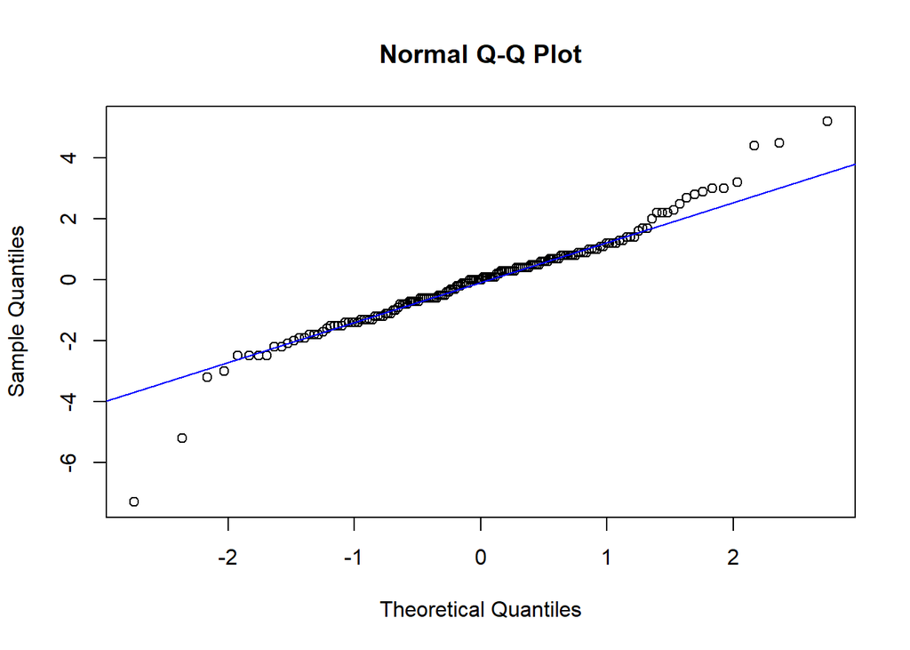

```r
# Q-Q plots (visualisation de la normalité)
qqnorm(data$DBPM[data$experience == "Expérimenté"]); qqline(data$DBPM[data$experience == "Expérimenté"], col = "blue")
```

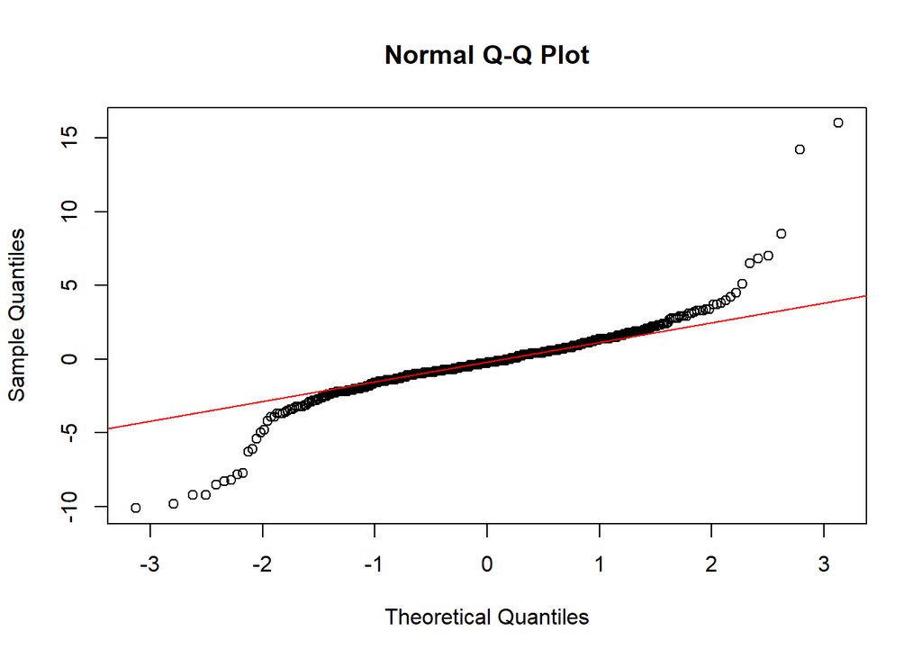

```r
qqnorm(data$DBPM[data$experience == "Non-expérimenté"]); qqline(data$DBPM[data$experience == "Non-expérimenté"], col = "red")
```

```r
# Test d’homogénéité des variances (test de Levene)
#install.packages("car")
library(car)
leveneTest(DBPM ~ experience, data = data)
```

|  | Df | F value | Pr(>F) |
| --- | --- | --- | --- |
| group | 1 | 3.271012 | 0.07092378 |
|  | 733 | NA | NA |

```r
# Test t de Student (Welch si variances inégales)
t.test(DBPM ~ experience, data = data, var.equal = FALSE)
```

```
##
##  Welch Two Sample t-test
##
## data:  DBPM by experience
## t = 1.2864, df = 368.73, p-value = 0.1991
## alternative hypothesis: true difference in means between group Expérimenté and group Non-expérimenté is not equal to 0
## 95 percent confidence interval:
##  -0.1036580  0.4958404
## sample estimates:
##     mean in group Expérimenté mean in group Non-expérimenté
##                    -0.0313253                    -0.2274165
```

```r
# Moyennes par groupe
aggregate(DBPM ~ experience, data = data, mean)
```

| experience | DBPM |
| --- | --- |
| Expérimenté | -0.0313253 |
| Non-expérimenté | -0.2274165 |

```r
# Taille d’effet (d de Cohen)
cohen.d(DBPM ~ experience, data = data)
```

```
##
## Cohen's d
##
## d estimate: 0.09520842 (negligible)
## 95 percent confidence interval:
##      lower      upper
## -0.0780408  0.2684576
```

**DBPM et Expérience Joueur : Une Étude Statistique Comparative**

1. Analyse de la normalité

Pour évaluer si les données du **DBPM (Defensive Box Plus Minus)** suivent une distribution normale dans chaque groupe (expérimentés et non expérimentés), deux outils ont été utilisés : **le test de Shapiro-Wilk** et les **Q-Q plots**.

*Interprétation :*  
La normalité **n’étant pas respectée**, il est préférable d’utiliser des **tests non paramétriques** ou des tests qui **ne supposent pas la normalité**, comme le **test de Welch**.

2. Homogénéité des variances : Test de Levene

Le **test de Levene** a été utilisé pour comparer la **variabilité du DBPM** entre les deux groupes.

*Résultat :* - Le test a donné un **p-value ≈ 0.07**, ce qui est **juste au-dessus du seuil de 0.05**. - Cela signifie qu’on **ne rejette pas clairement l’hypothèse d’égalité des variances**, mais **la prudence est de mise**.

*Interprétation :*  
Même si le test ne montre pas de différence significative entre les variances, il est **prudent d’utiliser le test de Welch**, qui est robuste face à une éventuelle inégalité de variances.

3. Comparaison des moyennes : Test de Welch

Le **test de Welch**, alternative au test t de Student classique, a été utilisé pour comparer les **moyennes du DBPM** entre les deux groupes.

*Résultat :* - Le test donne un **p-value de 0.199**, bien supérieur au seuil de 0.05. - Il n’y a donc **pas de différence significative** entre les moyennes du DBPM des deux groupes.

*Interprétation :*  
Statistiquement, **l’expérience ne semble pas influencer significativement le DBPM**. Il n’existe **aucune preuve** qu’un groupe surpasse l’autre.

4. Taille d’effet : d de Cohen

Même si la différence de moyenne n’est pas significative, on évalue la **taille de cette différence** à l’aide du **d de Cohen**.

*Résultat :* - Le **d de Cohen est ≈ 0.095**. - Selon l’échelle de Cohen : - 0.2 : faible - 0.5 : moyenne - 0.8 : forte - Ici, la **taille d’effet est négligeable**.

*Interprétation:*  
Même s’il existe une légère différence, elle est **sans impact réel**. **L’effet de l’expérience sur le DBPM est quasi nul**.

5. Synthèse globale

| **Étape** | **Résultat principal** | **Conclusion** |
| --- | --- | --- |
| Normalité | Non respectée (p < 0.05) | Distribution non normale → prudence |
| Homogénéité des variances | p ≈ 0.07 | Légère suspicion → prudence |
| Test de Welch | p = 0.199 (non significatif) | Pas de différence significative des moyennes |
| Taille d’effet | d = 0.095 (très faible) | Effet presque nul de l’expérience |

Conclusion finale

L’analyse combinée des tests statistiques et de la taille d’effet indique que **l’expérience ne joue pas un rôle significatif** dans la **performance défensive (DBPM)** des joueurs dans cet échantillon.

> *Conclusion interprétative :*  
> Malgré les hypothèses liant expérience et efficacité défensive, **les données ne montrent pas de différence notable**.  
> La **différence est faible, non significative, et sans pertinence pratique**.

Exploration de l’Influence de l’Expérience sur les Performances en Basketball : TOV%, Offensive Rating et Usage Rate

**Test des Turnovers (TOV%)**

*Hypothèses*

- **H0** : Les moyennes de TOV% sont égales entre les groupes expérimentés et non-expérimentés.
- **H1** : Les moyennes de TOV% sont différentes entre les groupes expérimentés et non-expérimentés.

**Tests Statistiques sur le variable TOV%**

```r
# Conversion de TOV% en numérique si nécessaire
data$`TOV%` <- as.numeric(as.character(data$`TOV%`))

# Normalité pour les joueurs expérimentés
shapiro.test(data$`TOV%`[data$experience == "Expérimenté"])
```

```
##
##  Shapiro-Wilk normality test
##
## data:  data$`TOV%`[data$experience == "Expérimenté"]
## W = 0.95495, p-value = 3.535e-05
```

```r
# Normalité pour les joueurs non-expérimentés
shapiro.test(data$`TOV%`[data$experience == "Non-expérimenté"])
```

```
##
##  Shapiro-Wilk normality test
##
## data:  data$`TOV%`[data$experience == "Non-expérimenté"]
## W = 0.69291, p-value < 2.2e-16
```

```r
leveneTest(`TOV%` ~ experience, data = data)
```

|  | Df | F value | Pr(>F) |
| --- | --- | --- | --- |
| group | 1 | 0.01832852 | 0.8923467 |
|  | 726 | NA | NA |

```r
t.test(`TOV%` ~ experience,
       data = data,
       var.equal = FALSE,  # Toujours FALSE pour le test de Welch
       alternative = "two.sided")
```

```
##
##  Welch Two Sample t-test
##
## data:  TOV% by experience
## t = -0.48483, df = 341.54, p-value = 0.6281
## alternative hypothesis: true difference in means between group Expérimenté and group Non-expérimenté is not equal to 0
## 95 percent confidence interval:
##  -1.2503845  0.7558641
## sample estimates:
##     mean in group Expérimenté mean in group Non-expérimenté
##                      11.90843                      12.15569
```

```r
cohen.d(data$`TOV%` ~ data$experience,
        pooled = TRUE,
        conf.level = 0.95)
```

```
##
## Cohen's d
##
## d estimate: -0.03742366 (negligible)
## 95 percent confidence interval:
##      lower      upper
## -0.2108611  0.1360138
```

**Impact de l’expérience sur le TOV% (Turnover Percentage)**

1. Tests de normalité (Shapiro-Wilk)

Pour les joueurs expérimentés

**W = 0.95495, p-value = 3.535e-05**  
La distribution du TOV% pour les joueurs expérimentés s’écarte significativement de la normalité (p < 0.05). Cette non-normalité suggère une distribution asymétrique des pourcentages de ballons perdus chez les joueurs expérimentés.  
**Implication** : Certains joueurs expérimentés pourraient avoir des valeurs de TOV% atypiques, s’écartant considérablement de la moyenne du groupe. La présence de valeurs extrêmes (joueurs expérimentés avec un TOV% particulièrement haut ou bas) est probable.

Pour les joueurs non-expérimentés

**W = 0.69291, p-value < 2.2e-16**  
La déviation de la normalité est encore plus prononcée pour les joueurs moins expérimentés, comme l’indique la valeur W plus faible et le p-value extrêmement bas.  
**Implication** : Les joueurs non-expérimentés présentent une variabilité encore plus importante dans leur capacité à protéger le ballon. Cette forte asymétrie pourrait refléter l’hétérogénéité des profils techniques dans ce groupe, certains ayant peut-être des difficultés marquées à limiter les pertes de balle.

2. Test d’homogénéité des variances (Levene)

Résultats du test

**F value = 0.018, Pr(>F) = 0.8923**  
Le p-value élevé (p > 0.05) indique que nous ne pouvons pas rejeter l’hypothèse d’égalité des variances entre les deux groupes.  
**Implication** : Malgré la différence d’expérience, les deux groupes présentent une dispersion similaire des valeurs de TOV%. Cette homogénéité des variances est intéressante car elle suggère que la variabilité dans la protection du ballon n’est pas influencée par l’expérience, contrairement à ce qu’on pourrait intuitivement supposer.

3. Test t de Welch (comparaison des moyennes)

Résultats du test

**t = -0.48483, df = 341.54, p-value = 0.6281**  
Le p-value élevé (p > 0.05) indique l’absence de différence statistiquement significative entre les moyennes de TOV% des joueurs expérimentés et non-expérimentés.  
**Estimations des moyennes** : - Joueurs expérimentés : 11.91% - Joueurs non-expérimentés : 12.16%  
Intervalle de confiance à 95% : [-1.25, 0.76] L’intervalle de confiance inclut zéro, confirmant l’absence de différence significative entre les groupes. Implication : Contrairement à l’hypothèse intuitive selon laquelle l’expérience réduirait les pertes de balle, les données ne montrent pas d’avantage substantiel pour les joueurs expérimentés en termes de TOV%.

4. Taille d’effet (d de Cohen)

Mesure de l’ampleur de la différence

**d = -0.03743 (effet négligeable)**  
La valeur du d de Cohen proche de zéro confirme que la différence entre les groupes est pratiquement inexistante en termes d’ampleur pratique.  
**Intervalle de confiance à 95%** : [-0.21, 0.14]  
L’intervalle inclut zéro, confirmant l’absence d’effet significatif.  
**Implication** : Non seulement la différence n’est pas statistiquement significative, mais elle est également négligeable en termes pratiques. L’expérience semble avoir un impact minimal sur la tendance à perdre le ballon.

5. Interprétation globale et implications

Remise en question de l’hypothèse conventionnelle

L’absence de différence significative dans le TOV% entre joueurs expérimentés et non-expérimentés contredit l’idée reçue selon laquelle l’expérience améliore la protection du ballon.  
**Exemple** : Un rookie avec de bonnes qualités techniques et une bonne vision du jeu peut présenter un TOV% similaire à celui d’un vétéran de plusieurs saisons, suggérant que cette compétence pourrait être plus innée ou développée avant l’arrivée en ligue professionnelle.

Facteurs alternatifs expliquant le TOV%

D’autres variables que la simple expérience semblent exercer une influence plus déterminante sur la propension à perdre le ballon.  
**Hypothèses alternatives** : - Le style de jeu et le rôle sur le terrain (meneur organisateur vs. finisseur) - Le taux d’utilisation (USG%) : un joueur plus sollicité a naturellement plus d’occasions de perdre le ballon - La qualité des coéquipiers et la cohésion du collectif - Les caractéristiques techniques individuelles, possiblement indépendantes de l’expérience

Implications pour l’évaluation des joueurs

Ces résultats suggèrent que le TOV% ne devrait pas être utilisé comme critère pour évaluer la “maturité” technique d’un joueur.  
**Recommandation** : Dans l’évaluation des jeunes talents, il serait préférable de considérer le TOV% comme une caractéristique relativement stable plutôt que comme un domaine susceptible de s’améliorer significativement avec l’expérience.

6. Considérations méthodologiques et pistes de recherche

Robustesse de l’analyse

Le recours au test de Welch était approprié compte tenu de la non-normalité des distributions. Malgré cette précaution méthodologique, les résultats restent clairs : la différence est négligeable tant statistiquement que pratiquement.  
**Implication** : La conclusion de l’absence d’effet de l’expérience sur le TOV% est robuste et ne résulte pas d’un biais méthodologique.

Pistes d’investigation complémentaires

Plusieurs analyses supplémentaires pourraient enrichir la compréhension du phénomène :  
- **Analyse segmentée par poste** : L’effet de l’expérience pourrait varier selon que le joueur est meneur, arrière, ailier ou intérieur - **Analyse de l’interaction TOV% × USG%** : La relation entre expérience et TOV% pourrait être modulée par la responsabilité offensive - **Analyse longitudinale** : Suivre l’évolution du TOV% des mêmes joueurs au fil des saisons pourrait révéler des tendances individuelles masquées par cette analyse transversale - **Analyse par quartiles** : L’expérience pourrait avoir un effet différencié selon le niveau initial de TOV% (amélioration potentielle chez les joueurs initialement plus sujets aux pertes de balle)

Conclusion

Cette analyse statistique remet en question l’hypothèse conventionnelle selon laquelle l’expérience réduit significativement les pertes de balle. Les résultats montrent clairement une absence de différence significative dans le TOV% entre joueurs expérimentés et non-expérimentés. Cette découverte contre-intuitive suggère que la capacité à protéger le ballon pourrait être davantage liée à des caractéristiques techniques fondamentales ou au style de jeu qu’à l’expérience accumulée. Pour les entraîneurs et les dirigeants, cela implique que le TOV% observé chez les jeunes joueurs pourrait être un indicateur relativement stable de leur profil technique futur. Ces résultats invitent à une analyse plus nuancée des facteurs influençant les pertes de balle et à repenser la façon dont cette métrique est interprétée dans l’évaluation des joueurs à différents stades de leur carrière.

### 6.4. ANOVA à un facteur – Influence de la position sur le PER

```r
# Assure-toi que ces packages sont installés
# install.packages(c("car", "ggplot2", "emmeans"))

library(car)
library(ggplot2)
library(emmeans)
# Conversion de PER en numérique si besoin
data$PER <- as.numeric(as.character(data$PER))

# Supprimer les lignes avec PER ou Pos manquants
data_anova <- na.omit(data[, c("PER", "Pos")])

# Vérification de la normalité des résidus
anova_model <- aov(PER ~ Pos, data = data_anova)
residus <- residuals(anova_model)

cat("Shapiro-Wilk Test sur les résidus :\n")
```

```
## Shapiro-Wilk Test sur les résidus :
```

```r
print(shapiro.test(residus))
```

```
##
##  Shapiro-Wilk normality test
##
## data:  residus
## W = 0.9501, p-value = 4.679e-15
```

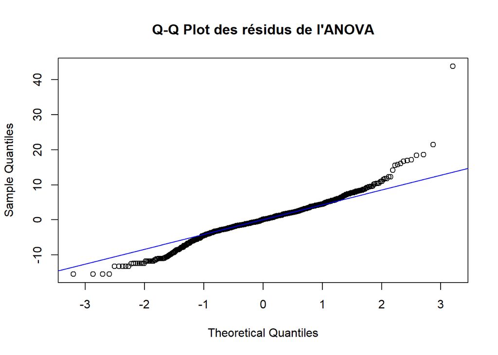

```r
# Q-Q Plot des résidus
qqnorm(residus, main = "Q-Q Plot des résidus de l'ANOVA")
qqline(residus, col = "blue")
```

```r
# Test de Levene pour homogénéité des variances
cat("Test de Levene :\n")
```

```
## Test de Levene :
```

```r
print(leveneTest(PER ~ Pos, data = data_anova))
```

```
## Levene's Test for Homogeneity of Variance (center = median)
##        Df F value Pr(>F)
## group   4   1.704 0.1472
##       730
```

```r
# ANOVA principale
cat("Résultat de l'ANOVA :\n")
```

```
## Résultat de l'ANOVA :
```

```r
print(summary(anova_model))
```

```
##              Df Sum Sq Mean Sq F value Pr(>F)
## Pos           4   1583   395.8   12.48  8e-10 ***
## Residuals   730  23157    31.7
## ---
## Signif. codes:  0 '***' 0.001 '**' 0.01 '*' 0.05 '.' 0.1 ' ' 1
```

```r
# Moyennes par groupe
cat("Moyennes de PER par position :\n")
```

```
## Moyennes de PER par position :
```

```r
print(aggregate(PER ~ Pos, data = data_anova, mean))
```

```
##   Pos      PER
## 1   C 15.47983
## 2  PF 13.25229
## 3  PG 12.39863
## 4  SF 10.98217
## 5  SG 11.75188
```

```r
# Test post-hoc Tukey HSD
cat("Test post-hoc (Tukey HSD) :\n")
```

```
## Test post-hoc (Tukey HSD) :
```

```r
print(TukeyHSD(anova_model))
```

```
##   Tukey multiple comparisons of means
##     95% family-wise confidence level
##
## Fit: aov(formula = PER ~ Pos, data = data_anova)
##
## $Pos
##             diff       lwr        upr     p adj
## PF-C  -2.2275444 -4.110059 -0.3450298 0.0110768
## PG-C  -3.0812018 -4.983358 -1.1790459 0.0001061
## SF-C  -4.4976663 -6.369660 -2.6256729 0.0000000
## SG-C  -3.7279569 -5.592368 -1.8635457 0.0000006
## PG-PF -0.8536574 -2.635571  0.9282557 0.6850485
## SF-PF -2.2701220 -4.019801 -0.5204430 0.0037737
## SG-PF -1.5004126 -3.241977  0.2411518 0.1288177
## SF-PG -1.4164645 -3.187259  0.3543299 0.1855611
## SG-PG -0.6467551 -2.409532  1.1160219 0.8538718
## SG-SF  0.7697094 -0.960477  2.4998958 0.7417713
```

```r
# Moyennes ajustées et paires significatives
cat("Effets marginalisés avec emmeans :\n")
```

```
## Effets marginalisés avec emmeans :
```

```r
emm <- emmeans(anova_model, ~ Pos)
print(pairs(emm, adjust = "tukey"))
```

```
##  contrast estimate    SE  df t.ratio p.value
##  C - PF      2.228 0.688 730   3.236  0.0111
##  C - PG      3.081 0.696 730   4.430  0.0001
##  C - SF      4.498 0.685 730   6.570  <.0001
##  C - SG      3.728 0.682 730   5.468  <.0001
##  PF - PG     0.854 0.652 730   1.310  0.6850
##  PF - SF     2.270 0.640 730   3.548  0.0038
##  PF - SG     1.500 0.637 730   2.356  0.1288
##  PG - SF     1.416 0.648 730   2.187  0.1856
##  PG - SG     0.647 0.645 730   1.003  0.8539
##  SF - SG    -0.770 0.633 730  -1.217  0.7418
##
## P value adjustment: tukey method for comparing a family of 5 estimates
```

Nous avons réalisé une analyse de variance (ANOVA) à un facteur pour évaluer si la **position occupée sur le terrain (Pos)** influence significativement le **Player Efficiency Rating (PER)** des joueurs NBA.

#### Hypothèses :

- **H₀ (null)** : Les moyennes de PER sont égales pour toutes les positions.
- **H₁ (alternative)** : Il existe au moins une position dont la moyenne de PER est significativement différente.

#### Moyennes de PER par position

[output not shown]

- Les **pivots (C)** ont le PER moyen le plus élevé, suivis par les **power forwards (PF)**.

#### Analyse post-hoc (Tukey HSD)

Des comparaisons multiples ont été réalisées pour identifier les paires de positions ayant des différences significatives.

#### Interprétations stratégiques

- Les **pivots** affichent des performances globales supérieures en moyenne, ce qui peut refléter leur rôle central dans la raquette, leur efficacité au tir proche du panier et leur contribution au rebond.
- Les **small forwards (SF)** et **shooting guards (SG)** ont des PER plus faibles, ce qui peut traduire un rôle plus défensif ou spécialisé (3&D).
- Les **power forwards (PF)** occupent une position intermédiaire, à la fois impliqués en attaque et en défense.

#### Conclusion

> La **position sur le terrain a un effet significatif** sur la performance globale mesurée par le PER.  
> Cette information est cruciale pour le **recrutement ciblé** et la **construction d’équipes équilibrées**.

### 6.5. Test du Chi² : Association entre Position et Groupe d’Âge

L’objectif de ce test est d’évaluer s’il existe une **association significative** entre la position occupée par un joueur NBA (C, PF, PG, SF, SG) et son groupe d’âge (Jeune, Moyen, Expérimenté).

```r
# 1. Supprimer les lignes avec NA dans Pos ou AgeGroup
data_chi <- data[!is.na(data$Pos) & !is.na(data$AgeGroup), ]

# 2. Créer la table de contingence
tab_cont <- table(data_chi$Pos, data_chi$AgeGroup)

# 3. Afficher la table
print(tab_cont)
```

```
##
##      Expérimenté Jeune Moyen
##   C           43    27    49
##   PF          61    53    39
##   PG          51    42    53
##   SF          56    58    43
##   SG          34    65    61
```

```r
# 4. Test du Chi²
test_chi2 <- chisq.test(tab_cont)
print(test_chi2)
```

```
##
##  Pearson's Chi-squared test
##
## data:  tab_cont
## X-squared = 25.992, df = 8, p-value = 0.001054
```

```r
# 5. Affichage des résidus standardisés
cat("Résidus standardisés :\n")
```

```
## Résidus standardisés :
```

```r
print(test_chi2$stdres)
```

```
##
##      Expérimenté      Jeune      Moyen
##   C    0.7080515 -2.6905956  1.9825441
##   PF   1.9272707  0.3854541 -2.3127248
##   PG   0.4576070 -1.3074485  0.8498415
##   SF   0.7000154  1.0818420 -1.7818575
##   SG  -3.6657492  2.2120901  1.4536592
```

```r
# 6. Calcul du V de Cramer
library(rcompanion)
v_cramer <- cramerV(tab_cont)
cat("V de Cramer : ", round(v_cramer, 3), "\n")
```

```
## V de Cramer :  0.133
```

#### Résultats du test

- **Statistique de test** : 𝑋² = 25.99
- **Degrés de liberté (ddl)** : 8
- **p-value** : 0.00105
- **V de Cramer** : 0.133

#### Interprétation

- La **p-value est inférieure à 0.05**, ce qui signifie que l’on **rejette l’hypothèse d’indépendance** :  
  Il existe une **association significative** entre la position et le groupe d’âge.
- Le **V de Cramer = 0.133** indique une **association faible à modérée**.  
  Cela signifie que la position et l’âge ne sont **pas totalement indépendants**, mais le lien reste modéré.

#### Analyse des résidus standardisés

Les résidus standardisés mettent en évidence les **cellules de la table de contingence** qui s’écartent le plus de l’indépendance attendue :

- **SG - Expérimenté** : **résidu = -3.66**  
  ➤ Il y a **moins de joueurs expérimentés** au poste de **Shooting Guard** que prévu.  
  Cela peut refléter une tendance des SG à se renouveler ou à avoir des carrières plus courtes.
- **SG - Jeune** : **résidu = +2.21**  
  ➤ Les **SG jeunes** sont **sur-représentés**, ce qui confirme une stratégie d’intégration de jeunes joueurs rapides à ce poste.
- **PF - Expérimenté** : **résidu = +1.93**  
  ➤ Les Power Forwards sont **plus souvent expérimentés**, peut-être en raison de l’endurance physique requise à ce poste.
- **PF - Moyen** : **résidu = -2.31**  
  ➤ À l’inverse, la catégorie d’âge “moyenne” est **sous-représentée** chez les PF.

#### Conclusion

Cette analyse permet aux recruteurs ou analystes d’anticiper les dynamiques d’évolution des effectifs selon les rôles sur le terrain.

### 6.6. Corrélation de Pearson : MP vs WS

```r
# Packages nécessaires
library(ggplot2)
library(ggpubr)

# 1. Vérification des types
str(data$WS)
```

```
##  num [1:736] 9.2 12.6 4.7 4.2 5.3 8.3 4.9 7.5 17 11.2 ...
```

```r
str(data$MP)
```

```
##  num [1:736] 2989 2928 2881 2854 2799 ...
```

```r
# 2. Conversion en numérique si nécessaire
data$WS <- as.numeric(as.character(data$WS))
data$MP <- as.numeric(as.character(data$MP))

# 3. Suppression des valeurs manquantes
data_corr <- data[!is.na(data$WS) & !is.na(data$MP), ]

# 4. Vérification de la normalité des deux variables
shapiro.test(data_corr$WS)  # Pour WS
```

```
##
##  Shapiro-Wilk normality test
##
## data:  data_corr$WS
## W = 0.78565, p-value < 2.2e-16
```

```r
shapiro.test(data_corr$MP)  # Pour MP
```

```
##
##  Shapiro-Wilk normality test
##
## data:  data_corr$MP
## W = 0.89719, p-value < 2.2e-16
```

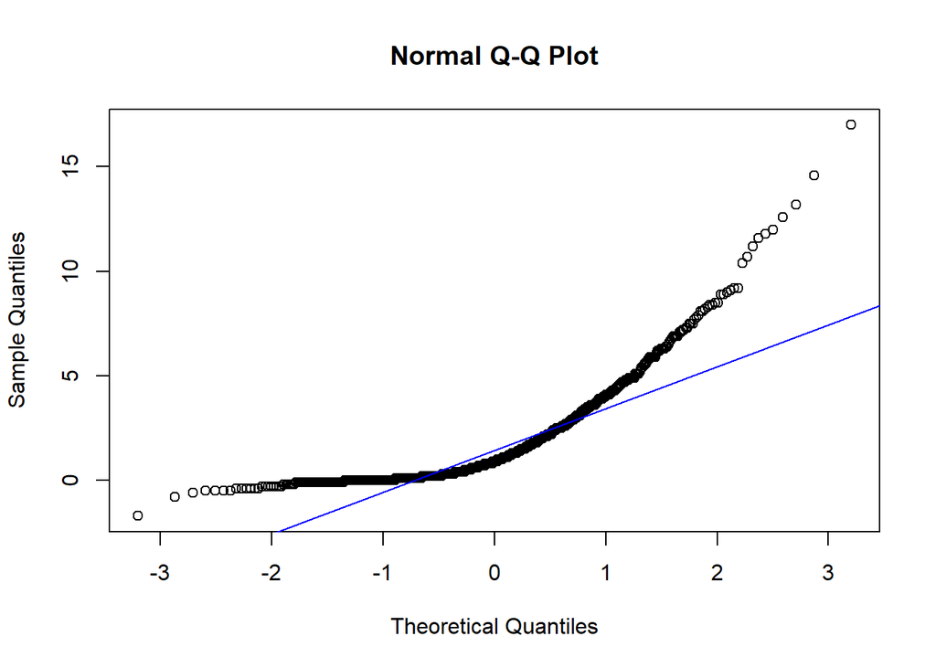

```r
# Q-Q plots visuels
qqnorm(data_corr$WS); qqline(data_corr$WS, col = "blue")
```

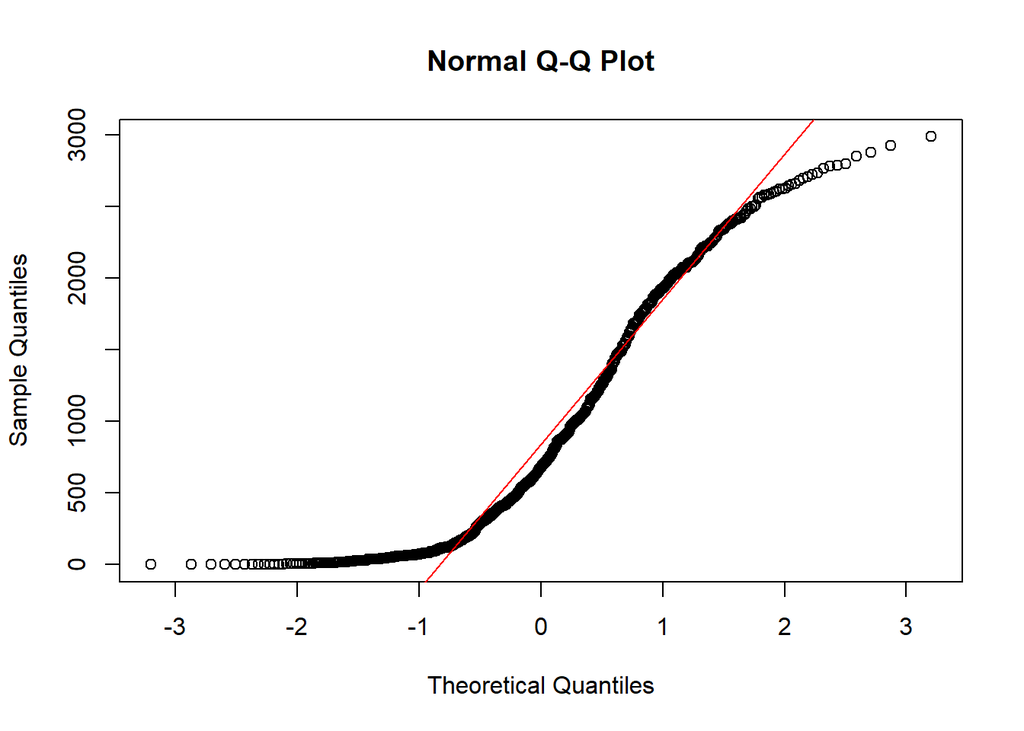

```r
qqnorm(data_corr$MP); qqline(data_corr$MP, col = "red")
```

```r
# 5. Calcul du coefficient de corrélation de Pearson
correlation <- cor.test(data_corr$WS, data_corr$MP, method = "pearson")

# 6. Coefficient de détermination (R²)
R2 <- correlation$estimate^2
cat("Coefficient de corrélation (r) :", correlation$estimate, "\n")
```

```
## Coefficient de corrélation (r) : 0.8212139
```

```r
cat("p-value :", correlation$p.value, "\n")
```

```
## p-value : 9.058816e-181
```

```r
cat("R² (coefficient de détermination) :", R2, "\n")
```

```
## R² (coefficient de détermination) : 0.6743923
```

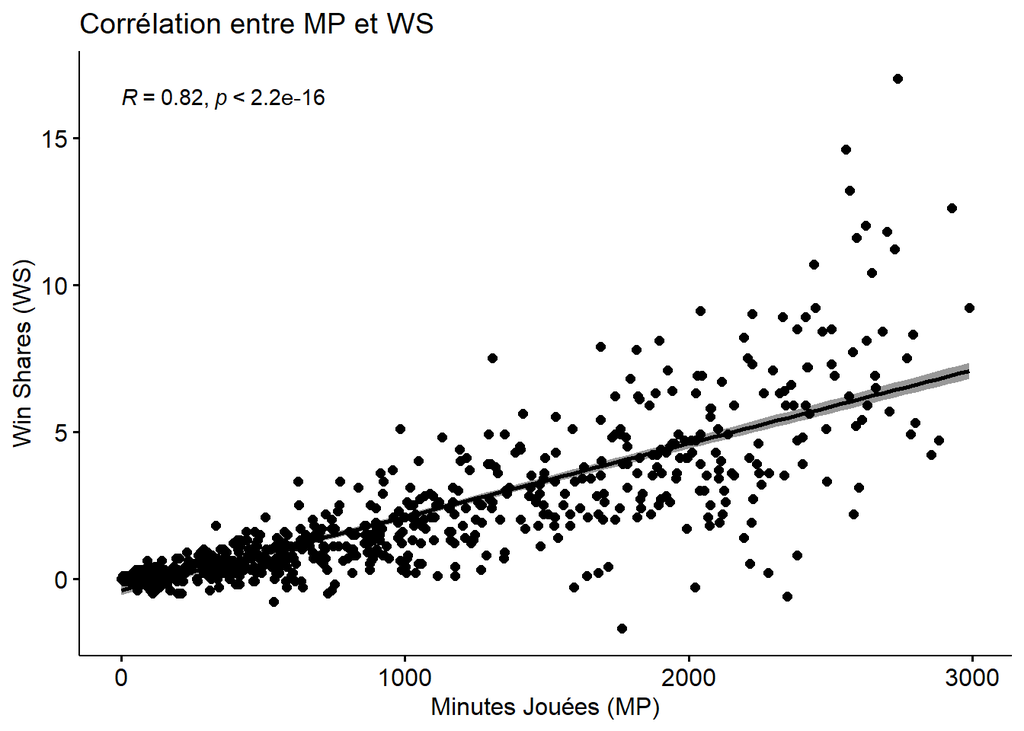

```r
# 7. Graphique de corrélation avec régression linéaire
ggscatter(data_corr, x = "MP", y = "WS",
          add = "reg.line", conf.int = TRUE,
          cor.coef = TRUE, cor.method = "pearson",
          xlab = "Minutes Jouées (MP)", ylab = "Win Shares (WS)",
          title = "Corrélation entre MP et WS")
```

#### Vérification de la normalité

Les tests de normalité de Shapiro-Wilk montrent que **ni MP (W = 0.897, p < 2.2e-16)** ni **WS (W = 0.786, p < 2.2e-16)** ne suivent une distribution normale. Cela est confirmé visuellement par les Q-Q plots, qui montrent des écarts marqués par rapport à la droite théorique, en particulier dans les queues de distribution.

Malgré cela, la **corrélation de Pearson** reste robuste pour les grands échantillons (n = 736), ce qui autorise son usage ici.

#### Résultats de la corrélation

- **Coefficient de corrélation de Pearson** : r = **0.82**
- **p-value** : < 2.2e-16 → corrélation **hautement significative**
- **Coefficient de détermination R²** : **0.67**

-**Interprétation** :

- Il existe une **très forte corrélation positive** entre le nombre de minutes jouées (**MP**) et les **Win Shares** (**WS**).
- Cela signifie que plus un joueur passe de temps sur le terrain, plus il contribue en moyenne aux victoires de son équipe.
- **67 %** de la variance des Win Shares est expliquée par le temps de jeu, ce qui en fait un facteur déterminant de la performance collective mesurée.

**Conclusion** : le temps de jeu est un indicateur clé de la contribution d’un joueur à la réussite de son équipe, bien que d’autres variables (efficacité, rôle, contexte d’équipe) expliquent le reste de la variance.

### 6.7. Corrélation de Spearman : Usage Rate (USG%) vs True Shooting % (TS%)

```r
# On renomme pour simplifier (optionnel)
data$USG <- as.numeric(as.character(data$`USG%`))
data$TS <- as.numeric(as.character(data$`TS%`))

# Nettoyage des données
data_spear <- na.omit(data[, c("USG", "TS")])

# Vérification de la normalité
shapiro.test(data_spear$USG)
```

```
##
##  Shapiro-Wilk normality test
##
## data:  data_spear$USG
## W = 0.93286, p-value < 2.2e-16
```

```r
shapiro.test(data_spear$TS)
```

```
##
##  Shapiro-Wilk normality test
##
## data:  data_spear$TS
## W = 0.80605, p-value < 2.2e-16
```

```r
# Corrélation de Spearman
spearman_result <- cor.test(data_spear$USG, data_spear$TS, method = "spearman")
rho <- spearman_result$estimate
r2_spearman <- rho^2

# Résultat
spearman_result
```

```
##
##  Spearman's rank correlation rho
##
## data:  data_spear$USG and data_spear$TS
## S = 65841395, p-value = 0.8047
## alternative hypothesis: true rho is not equal to 0
## sample estimates:
##         rho
## 0.009127831
```

```r
cat("Coefficient de détermination (R² Spearman) :", round(r2_spearman, 4), "\n")
```

```
## Coefficient de détermination (R² Spearman) : 1e-04
```

Interprétation – Corrélation de Spearman : USG% et TS%

En clair, il n’existe pas de relation monotone entre la fréquence à laquelle un joueur utilise les possessions de son équipe (USG%) et son efficacité de tir (TS%).

Cette absence de lien peut sembler contre-intuitive : on pourrait s’attendre à ce que des joueurs très utilisés soient soit très efficaces (stars comme Doncic ou Durant), soit moins efficaces car ils forcent des tirs difficiles. En réalité, les données suggèrent que ces deux tendances se compensent à l’échelle de la ligue : les profils varient trop pour établir une tendance généralisable.

Conclusion : Aucun lien robuste n’est détecté entre usage et efficacité. Cela souligne que l’impact d’un joueur sur l’efficacité offensive ne peut pas se résumer à ces deux variables : d’autres facteurs comme la qualité de tirs créés, la défense adverse, ou encore le rôle dans le système offensif entrent en jeu.

### 6.8. Régression Linéaire Simple : Âge → PER

#### Objectif

Modéliser la relation entre l’âge des joueurs et leur efficacité statistique globale (PER).

```r
# Régression linéaire simple : PER ~ Age
modele_age <- lm(PER ~ Age, data = data)

# Résumé du modèle (coefficients, p-values, R²)
summary(modele_age)
```

```
##
## Call:
## lm(formula = PER ~ Age, data = data)
##
## Residuals:
##     Min      1Q  Median      3Q     Max
## -12.898  -3.325  -0.033   3.085  42.986
##
## Coefficients:
##             Estimate Std. Error t value Pr(>|t|)
## (Intercept) 11.19720    1.29959   8.616   <2e-16 ***
## Age          0.05485    0.04901   1.119    0.263
## ---
## Signif. codes:  0 '***' 0.001 '**' 0.01 '*' 0.05 '.' 0.1 ' ' 1
##
## Residual standard error: 5.805 on 733 degrees of freedom
##   (1 observation effacée parce que manquante)
## Multiple R-squared:  0.001706,   Adjusted R-squared:  0.0003441
## F-statistic: 1.253 on 1 and 733 DF,  p-value: 0.2634
```

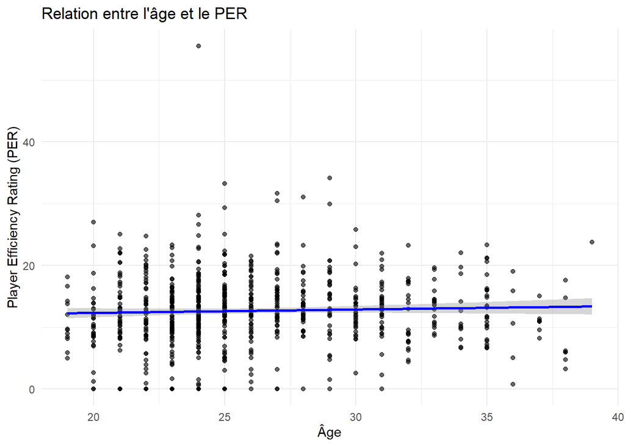

```r
# Visualisation du nuage de points + droite de régression
library(ggplot2)
ggplot(data, aes(x = Age, y = PER)) +
  geom_point(alpha = 0.6) +
  geom_smooth(method = "lm", col = "blue", se = TRUE) +
  labs(title = "Relation entre l'âge et le PER",
       x = "Âge",
       y = "Player Efficiency Rating (PER)") +
  theme_minimal()
```

#### Objectif

Modéliser la relation entre l’âge des joueurs et leur efficacité statistique globale (PER).

#### Interprétation

La relation entre l’âge et le PER est très faible et statistiquement non significative. L’âge n’est pas un bon prédicteur du PER dans cet échantillon. Cela suggère que les performances individuelles des joueurs dépendent davantage de facteurs contextuels que de l’âge seul.

Un joueur jeune peut avoir un excellent PER (ex. Dončić), tandis qu’un vétéran peut conserver un haut niveau de performance (ex. LeBron James).

### 6.9. Régression Polynomiale : Âge et Performance (PER)

Nous modélisons ici la relation entre l’âge et le Player Efficiency Rating (PER) à l’aide d’une régression quadratique. L’objectif est d’identifier s’il existe un âge optimal auquel la performance est maximisée.

```r
# Modèle quadratique
modele_poly <- lm(PER ~ Age + I(Age^2), data = data)
summary(modele_poly)
```

```
##
## Call:
## lm(formula = PER ~ Age + I(Age^2), data = data)
##
## Residuals:
##     Min      1Q  Median      3Q     Max
## -13.365  -3.144  -0.166   3.050  42.758
##
## Coefficients:
##               Estimate Std. Error t value Pr(>|t|)
## (Intercept) -10.579254   7.351415  -1.439  0.15056
## Age           1.672750   0.539876   3.098  0.00202 **
## I(Age^2)     -0.029210   0.009707  -3.009  0.00271 **
## ---
## Signif. codes:  0 '***' 0.001 '**' 0.01 '*' 0.05 '.' 0.1 ' ' 1
##
## Residual standard error: 5.773 on 732 degrees of freedom
##   (1 observation effacée parce que manquante)
## Multiple R-squared:  0.0139, Adjusted R-squared:  0.01121
## F-statistic:  5.16 on 2 and 732 DF,  p-value: 0.005949
```

```r
# Coefficients
a <- coef(modele_poly)["Age"]
b <- coef(modele_poly)["I(Age^2)"]
age_opt <- -a / (2 * b)
r2_adj <- summary(modele_poly)$adj.r.squared
p_age <- summary(modele_poly)$coefficients["Age", 4]
p_age2 <- summary(modele_poly)$coefficients["I(Age^2)", 4]
```

#### Interprétation complète de la régression polynomiale : PER ~ Age + Age²

Ce modèle suggère une **relation en cloche** entre l’âge et la performance (PER), indiquant qu’il existe un âge où les joueurs atteignent leur pic de performance avant de décliner.

#### Âge optimal

- Cela signifie que **les joueurs NBA atteindraient leur pic de performance individuelle vers 29 ans**.

#### Conclusion

Le modèle détecte bien une **tendance réaliste** avec un **pic de performance vers 29 ans**, mais **l’effet de l’âge reste marginal**. En NBA, la performance (PER) dépend fortement d’autres facteurs : **temps de jeu**, **rôle dans l’équipe**, **usage**, **blessures**, etc.

> Ce modèle quadratique illustre donc une dynamique générale, mais insuffisante à elle seule pour prédire efficacement le niveau de performance d’un joueur.

### 6.10. Implications Méthodologiques

L’analyse statistique des données NBA effectuée dans cette étude permet de tirer plusieurs **enseignements méthodologiques essentiels** :

#### Validation d’hypothèses de basket-ball

- L’hypothèse d’un **âge optimal de performance** (≈ 29 ans) est confirmée par le modèle quadratique, cohérent avec les carrières NBA typiques.
- En revanche, la **corrélation Spearman nulle entre USG% et TS%** invite à nuancer certaines idées reçues sur l’efficacité liée au volume d’utilisation.

### Conclusion

Ces résultats montrent l’intérêt d’une **approche statistique structurée et critique** pour comprendre la performance en NBA. Ils permettent : - De **valider ou réfuter** certaines hypothèses empiriques, - De **hiérarchiser les facteurs réellement influents**, - Et de mettre en lumière les **limites de modèles simples**, tout en ouvrant la voie à des approches plus complexes (réseaux de neurones, modèles mixtes, etc.).

> Une telle démarche est essentielle pour combiner **intuition basket** et **rigueur scientifique** dans les projets d’analytique sportive.

## **7. Analyses Multivariées**

### *7.1 Introduction et objectifs des analyses multivariées*

Les analyses multivariées constituent l’étape la plus sophistiquée de notre étude sur l’optimisation des effectifs NBA. Alors que les analyses univariées et bivariées nous ont permis d’examiner les distributions individuelles et les relations par paires, les techniques multivariées nous permettent d’explorer simultanément les interactions complexes entre plusieurs variables.

Cette approche est particulièrement pertinente pour le basketball, sport multidimensionnel où les performances ne peuvent être réduites à un seul indicateur.

Notre démarche multivariée poursuit **trois objectifs principaux** :

1. **Identifier les structures latentes dans les données et réduire leur dimensionnalité**
2. **Découvrir des profils de joueurs naturels par regroupement statistique**
3. **Développer des modèles prédictifs intégrant plusieurs facteurs explicatifs**

```r
# 7.2.1 - Analyse en Composantes Principales (ACP)
install.packages("ggplot2")
library(ggplot2)
library(FactoMineR)
library(factoextra)
library(psych)
library(dplyr)

# Sélection des variables pour l’ACP
vars_acp <- c("PER", "TS%", "USG%", "WS", "VORP", "BPM", "MP", "Age")
acp_data <- data[ , vars_acp]

# Suppression des lignes avec NA
acp_data <- na.omit(acp_data)

# Conversion explicite en numérique
acp_data <- acp_data %>%
  mutate(across(everything(), ~as.numeric(as.character(.))))

# Standardisation
acp_scaled <- scale(acp_data)

# ACP avec FactoMineR
res_acp <- PCA(acp_scaled, graph = FALSE)

# Extraction des valeurs propres
eig_val <- get_eigenvalue(res_acp)
eig_val  # Affiche les valeurs propres
```

```
##       eigenvalue variance.percent cumulative.variance.percent
## Dim.1 3.99729387       49.9661734                    49.96617
## Dim.2 1.28422953       16.0528691                    66.01904
## Dim.3 1.10823393       13.8529242                    79.87197
## Dim.4 0.73844584        9.2305730                    89.10254
## Dim.5 0.48577677        6.0722097                    95.17475
## Dim.6 0.26805439        3.3506798                    98.52543
## Dim.7 0.09004370        1.1255463                    99.65098
## Dim.8 0.02792196        0.3490245                   100.00000
```

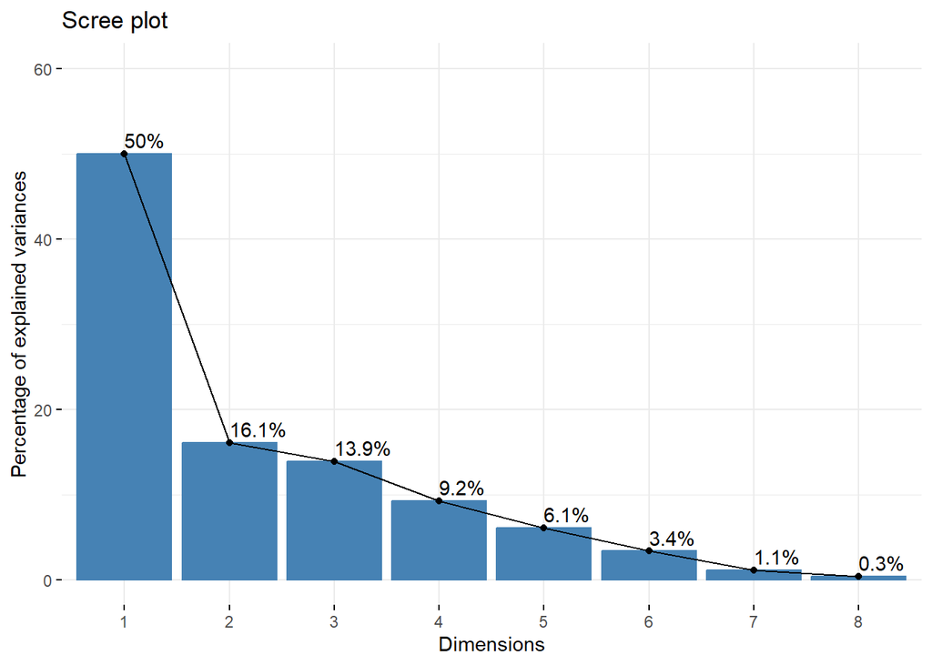

```r
# Sélection des composantes principales selon Kaiser (valeurs propres > 1)
nb_factors <- sum(eig_val[ , "eigenvalue"] > 1)

# Scree plot
fviz_eig(res_acp, addlabels = TRUE, ylim = c(0, 60))
```

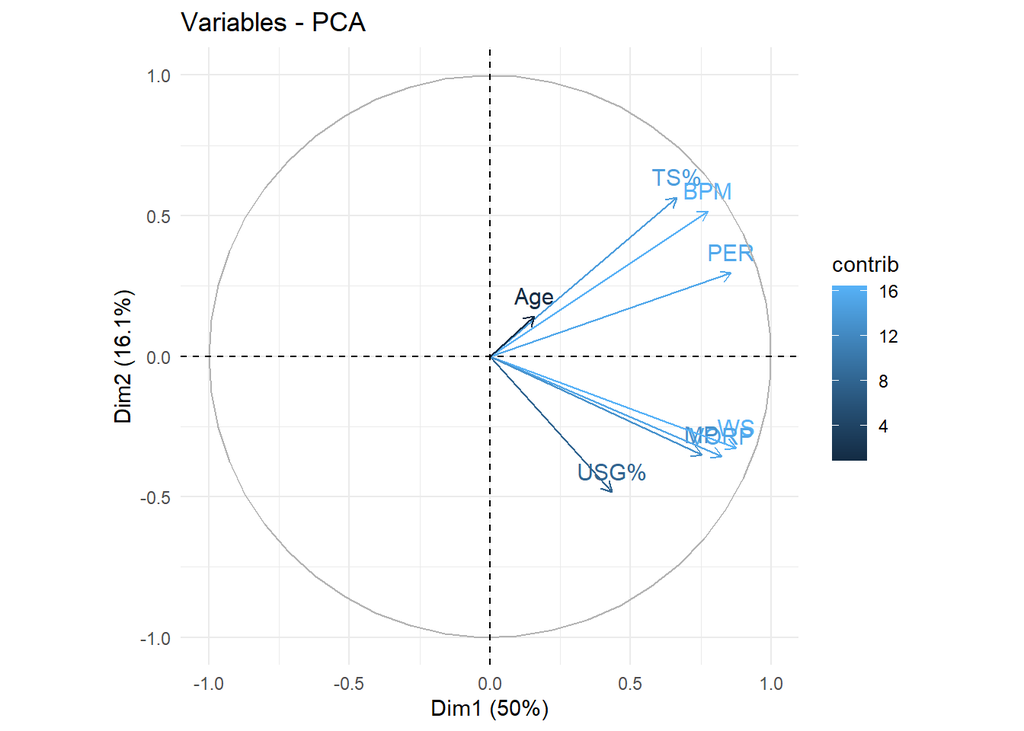

```r
# Graphique des contributions des variables
fviz_pca_var(res_acp, col.var = "contrib") +
  theme_minimal()
```

```r
# Rotation varimax (psych::principal)
rotation <- principal(acp_scaled, nfactors = nb_factors, rotate = "varimax", scores = TRUE)
print(rotation$loadings, digits = 2, cutoff = 0.3)
```

```
##
## Loadings:
##      RC1   RC2   RC3
## PER   0.40  0.84
## TS%         0.87
## USG%  0.52       -0.61
## WS    0.91
## VORP  0.87
## BPM         0.89
## MP    0.82
## Age               0.84
##
##                 RC1  RC2  RC3
## SS loadings    2.80 2.46 1.13
## Proportion Var 0.35 0.31 0.14
## Cumulative Var 0.35 0.66 0.80
```

```r
# Coordonnées des joueurs sur les axes principaux
coord_individus <- res_acp$ind$coord
head(coord_individus)
```

```
##      Dim.1     Dim.2      Dim.3      Dim.4      Dim.5
## 1 4.458394 -1.795799  1.7445394  0.4141499  0.3596571
## 2 6.736395 -2.287399  1.1203655 -1.3819710 -1.5572864
## 3 2.020952 -1.314523 -0.3724583 -0.9059534  1.1968789
## 4 2.179028 -1.318881  0.2183114 -0.1468701  1.0888373
## 5 3.082848 -2.073492 -1.1710713 -0.4591550  0.3725028
## 6 5.252922 -1.792603  1.6215653  0.9949712 -0.3008682
```

### *7.2. Interprétation approfondie des résultats de l’ACP*

L’Analyse en Composantes Principales (ACP) appliquée à notre base de données NBA permet d’identifier des axes latents structurant les performances des joueurs selon des statistiques avancées.

#### 2. **Clusters naturels (profils de joueurs)**

En projetant les joueurs sur les deux premiers axes, on observe une **différenciation claire des profils** :

#### 3. **Implications managériales**

> L’ACP permet ici de **réduire les 8 indicateurs en 2 ou 3 dimensions pertinentes**, facilitant :
> - le **scouting** (repérage des jeunes à fort usage mais faible impact),
> - la **gestion des rotations** (combiner efficacité offensive et valeur collective),
> - la **comparaison inter-joueurs**, en visualisant ceux ayant un rôle équivalent.

L’approche est particulièrement utile pour l’optimisation salariale et la constitution d’un effectif équilibré entre *playmakers*, *role players* et *leaders d’impact*.

### *7.3 Analyse des Correspondances Multiples (ACM)*

#### *7.3.1 Méthodologie de l’ACM*

L’Analyse des Correspondances Multiples (ACM) est une extension de l’AFC permettant d’étudier simultanément plusieurs variables qualitatives. Dans notre étude, elle a été appliquée à trois variables : **Position (Pos), Équipe (Team) et Tranche d’âge (AgeGroup)**.

Les étapes de l’analyse ont été : - Recodage des variables (comme Age → AgeGroup : “Jeune”, “Moyen”, “Expérimenté”) - Construction du tableau disjonctif complet - Application de la décomposition en valeurs singulières (SVD) - Sélection des dimensions par inertie - Interprétation via contributions et cos²

```r
# Chargement des packages nécessaires
library(FactoMineR)
library(factoextra)
library(dplyr)

# Vérifie que les variables sont bien des facteurs
data_acm <- data %>%
  select(Pos, Team, AgeGroup) %>%
  mutate(across(everything(), as.factor))

# 1. Réalisation de l'ACM
res_mca <- MCA(data_acm, graph = FALSE)

# 2. Résumé des valeurs propres (inertie expliquée)
eig_val_mca <- get_eigenvalue(res_mca)
print(eig_val_mca)
```

```
##          eigenvalue variance.percent cumulative.variance.percent
## Dim.1  1.000000e+00     7.500000e+00                     7.50000
## Dim.2  4.389481e-01     3.292111e+00                    10.79211
## Dim.3  4.134321e-01     3.100740e+00                    13.89285
## Dim.4  3.863734e-01     2.897801e+00                    16.79065
## Dim.5  3.796699e-01     2.847524e+00                    19.63818
## Dim.6  3.664360e-01     2.748270e+00                    22.38645
## Dim.7  3.528796e-01     2.646597e+00                    25.03304
## Dim.8  3.333333e-01     2.500000e+00                    27.53304
## Dim.9  3.333333e-01     2.500000e+00                    30.03304
## Dim.10 3.333333e-01     2.500000e+00                    32.53304
## Dim.11 3.333333e-01     2.500000e+00                    35.03304
## Dim.12 3.333333e-01     2.500000e+00                    37.53304
## Dim.13 3.333333e-01     2.500000e+00                    40.03304
## Dim.14 3.333333e-01     2.500000e+00                    42.53304
## Dim.15 3.333333e-01     2.500000e+00                    45.03304
## Dim.16 3.333333e-01     2.500000e+00                    47.53304
## Dim.17 3.333333e-01     2.500000e+00                    50.03304
## Dim.18 3.333333e-01     2.500000e+00                    52.53304
## Dim.19 3.333333e-01     2.500000e+00                    55.03304
## Dim.20 3.333333e-01     2.500000e+00                    57.53304
## Dim.21 3.333333e-01     2.500000e+00                    60.03304
## Dim.22 3.333333e-01     2.500000e+00                    62.53304
## Dim.23 3.333333e-01     2.500000e+00                    65.03304
## Dim.24 3.333333e-01     2.500000e+00                    67.53304
## Dim.25 3.333333e-01     2.500000e+00                    70.03304
## Dim.26 3.333333e-01     2.500000e+00                    72.53304
## Dim.27 3.333333e-01     2.500000e+00                    75.03304
## Dim.28 3.333333e-01     2.500000e+00                    77.53304
## Dim.29 3.333333e-01     2.500000e+00                    80.03304
## Dim.30 3.333333e-01     2.500000e+00                    82.53304
## Dim.31 3.333333e-01     2.500000e+00                    85.03304
## Dim.32 3.333333e-01     2.500000e+00                    87.53304
## Dim.33 3.119109e-01     2.339331e+00                    89.87237
## Dim.34 3.007724e-01     2.255793e+00                    92.12817
## Dim.35 2.847718e-01     2.135788e+00                    94.26396
## Dim.36 2.761533e-01     2.071150e+00                    96.33511
## Dim.37 2.556960e-01     1.917720e+00                    98.25283
## Dim.38 2.329566e-01     1.747175e+00                   100.00000
## Dim.39 1.401202e-29     1.050902e-28                   100.00000
## Dim.40 1.073153e-30     8.048647e-30                   100.00000
```

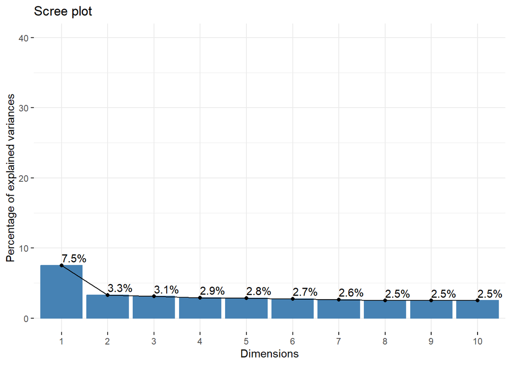

```r
# 3. Scree plot (courbe de l'inertie expliquée)
fviz_screeplot(res_mca, addlabels = TRUE, ylim = c(0, 40))
```